# IR, extinction, & counter conditioning

Analyses & meta-analyses

Ian Hussey & Sean Hughes

17 July 2020

# Dependencies & Functions

```r
# dependencies -----
library(tidyverse)
library(ggthemes)
library(knitr)
library(kableExtra)
library(broom)
library(effsize)
library(BayesFactor)
library(metafor)
library(ez)
library(schoRsch)
library(nnet)
library(epitools)

options(knitr.kable.NA = "/")

# Ensures that the processed data folder exists
dir.create("models")
dir.create("results")

# functions -----
# round p value using apa format
apa_p_value <- function(p){
  p_formatted <- ifelse(p >= 0.0001, paste("=", round(p, 4)),
                        ifelse(p < 0.0001, "< .0001", NA))
  p_formatted <- gsub(pattern = "0.", replacement = ".", x = p_formatted, fixed = TRUE)
  p_formatted
}

# calculate cohens d and return its output in tidy format - a helper function for analysis_workflow
tidy_cohens_d <- function(data){
  require(effsize)

  fit <- effsize::cohen.d(DV ~ IV, data = data)

  results <- tibble(cohens_d = fit$estimate,
                    cohens_d_ci_lower = fit$conf.int["lower"],
                    cohens_d_ci_upper = fit$conf.int["upper"])

  return(results)
}

# calculate cohens d and return its output in tidy format - a helper function for analysis_workflow
tidy_ttest_bf <- function(data){
  require(BayesFactor)

  fit <- data %>%
    ttestBF(formula = DV ~ IV, data = .)

  results <- data.frame(bf10 = extractBF(fit)$bf)
  return(results)
}


# full analysis workflow
# NB workflow returns mean_reference and mean_comparison, where reference is the first factor level and comparison is the next highest level.
analysis_workflow <- function(data){

  # frequentist t test
  results_t_test <- data %>%
    group_by(experiment, DV_type) %>%
    do(broom::tidy(t.test(DV ~ IV, data = .))) %>%
    ungroup() %>%
    rename(t = statistic,
           df = parameter,
           p = p.value,
           mean_reference = estimate1,
           mean_comaprison = estimate2)

  # cohens d
  results_cohens_d <- data %>%
    group_by(experiment, DV_type) %>%
    do(tidy_cohens_d(data = .)) %>%
    ungroup()

  # BF t test
  results_bf_t_test <- data %>%
    group_by(experiment, DV_type) %>%
    do(tidy_ttest_bf(data = .)) %>%
    ungroup()

  # combine
  results <-
    full_join(results_t_test,
              results_cohens_d,
              by = c("experiment", "DV_type")) %>%
    full_join(results_bf_t_test,
              by = c("experiment", "DV_type")) %>%
    select(experiment, DV_type,
           mean_reference, mean_comaprison,
           t, df, p, cohens_d, cohens_d_ci_lower, cohens_d_ci_upper, bf10) %>%
    mutate(reportable_result = paste0("Reference group M = ", round(mean_reference, 2), ", comparison group M = ", round(mean_comaprison, 2), ", t(", round(df, 2), ") = ", round(t, 2), ", p ", apa_p_value(p), ", d = ", round(cohens_d, 2), ", 95% CI [", round(cohens_d_ci_lower, 2), ", ", round(cohens_d_ci_upper, 2), "], BF10 = ", round(bf10, 1)))

  return(results)
}

# https://www.meta-analysis.com/downloads/Meta-analysis%20Converting%20among%20effect%20sizes.pdf
logOR_to_d <- function(logOR){
  logOR*(sqrt(3)/pi)
}
```

# Data and Exclusions

```r
# full data
data_processed <-
  bind_rows(
    read_csv("../data/Study 1/processed/data_processed.csv"),
    read_csv("../data/Study 2/processed/data_processed.csv"),
    read_csv("../data/Study 3/processed/data_processed.csv"),
    read_csv("../data/Study 4/processed/data_processed.csv"),
    read_csv("../data/Study 5/processed/data_processed.csv"),
    read_csv("../data/Study 6/processed/data_processed.csv"),
    read_csv("../data/Study 7/processed/data_processed.csv")
  ) %>%
  # set factor levels for t test comparisons
  mutate(experiment_condition = fct_relevel(experiment_condition,
                                            "acquisition_only",
                                            "acquisition_and_extinction",
                                            "acquisition_and_counterconditioning"),
         stimulus_identity_condition = fct_relevel(stimulus_identity_condition,
                                                   "Outcome_1_Target_1_Good_Outcome_2_Target_2_Bad",
                                                   "Outcome_1_Target_1_Bad_Outcome_2_Target_2_Good")) %>%
  # create compound exclusion variable
  mutate(exclude = ifelse(completeness_acquisition_training == "complete" &
                            completeness_acquisition_testing == "complete" &
                            (completeness_extinction_training == "complete" |
                               is.na(completeness_extinction_training)) &
                            (completeness_extinction_testing == "complete" |
                               is.na(completeness_extinction_testing)) &
                            (completeness_counterconditioning_training == "complete" |
                               is.na(completeness_counterconditioning_training)) &
                            (completeness_counterconditioning_testing == "complete" |
                               is.na(completeness_counterconditioning_testing)) &
                            complete_iat_data == "complete" &
                            passed_iat_performance == TRUE,
                          FALSE, TRUE),
         # if exclude variable is missing, then exclude
         exclude = ifelse(is.na(exclude), TRUE, exclude))

# exclusions
data_processed_after_exclusions <- data_processed %>%
  filter(exclude == FALSE)
```

# Demographics

```r
data_processed %>%
  group_by(experiment) %>%
  summarise(n = n(),
            age_mean = mean(age),
            age_sd = sd(age),
            excluded_n = sum(exclude),
            excluded_percent = mean(exclude*100)) %>%
  mutate_if(is.numeric, round, digits = 1) %>%
  kable(align = "c") %>%
  kable_styling(bootstrap_options = c("striped", "hover", "condensed"), full_width = FALSE)
```

| experiment | n | age_mean | age_sd | excluded_n | excluded_percent |
| --- | --- | --- | --- | --- | --- |
| 1 | 146 | 27.9 | 5.3 | 49 | 33.6 |
| 2 | 108 | 29.7 | 7.2 | 14 | 13.0 |
| 3 | 111 | 28.8 | 5.8 | 16 | 14.4 |
| 4 | 105 | 29.5 | 6.1 | 7 | 6.7 |
| 5 | 109 | 28.5 | 5.9 | 14 | 12.8 |
| 6 | 106 | 29.7 | 5.6 | 16 | 15.1 |
| 7 | 386 | 29.1 | 5.8 | 73 | 18.9 |

```r
data_processed %>%
  mutate(gender = str_remove_all(gender, "[0-9]"),
         gender = str_remove_all(gender, "-"),
         gender = ifelse(gender == "", NA, tolower(gender))) %>%
  count(experiment, gender) %>%
  spread(gender, n) %>%
  rename(female = f, male = m, missing = "<NA>") %>%
  kable(knitr.kable.NA = "/", align = "c") %>%
  kable_styling(bootstrap_options = c("striped", "hover", "condensed"), full_width = FALSE)
```

| experiment | agender | androgynous | female | male | nonbinary | private | missing |
| --- | --- | --- | --- | --- | --- | --- | --- |
| 1 | / | / | 53 | 93 | / | / | / |
| 2 | / | / | 57 | 51 | / | / | / |
| 3 | / | / | 66 | 44 | 1 | / | / |
| 4 | / | / | 50 | 54 | / | 1 | / |
| 5 | / | / | 38 | 69 | 1 | / | 1 |
| 6 | / | / | 57 | 48 | 1 | / | / |
| 7 | 1 | 1 | 222 | 161 | 1 | / | / |

# Training and testing mastery

## Percentage accuracy

```r
results_training_and_testing_percent_accuracy <- data_processed_after_exclusions %>%
  select(unique_id, experiment,
         mean_correct_acquisition_training,         mean_correct_acquisition_testing,
         mean_correct_extinction_training,          mean_correct_extinction_testing,
         mean_correct_counterconditioning_training, mean_correct_counterconditioning_testing) %>%
  gather(phase, mean_correct, c(mean_correct_acquisition_training, mean_correct_acquisition_testing,
                                mean_correct_extinction_training, mean_correct_extinction_testing,
                                mean_correct_counterconditioning_training, mean_correct_counterconditioning_testing)) %>%
  distinct(unique_id, phase, .keep_all = TRUE) %>%
  drop_na() %>%
  mutate(phase = dplyr::recode(phase,
                               "mean_correct_acquisition_training" = "Acquisition\ntraining",
                               "mean_correct_acquisition_testing" = "Acquisition\ntest",
                               "mean_correct_extinction_training" = "Extinction\ntraining",
                               "mean_correct_extinction_testing" = "Extinction\ntesting",
                               "mean_correct_counterconditioning_training" = "Counterconditioning\ntraining",
                               "mean_correct_counterconditioning_testing" = "Counterconditioning\ntesting")) %>%
  mutate(phase = as.factor(phase)) %>%
  mutate(phase = fct_relevel(phase, "Acquisition\ntraining",
                             "Acquisition\ntest",
                             "Extinction\ntraining",
                             "Extinction\ntesting",
                             "Counterconditioning\ntraining",
                             "Counterconditioning\ntesting")) %>%

  group_by(experiment, phase) %>%
  dplyr::summarise(mean_accuracy = mean(mean_correct*100, na.rm = TRUE),
                   sd_accuracy = sd(mean_correct*100, na.rm = TRUE)) %>%
  ungroup()

results_training_and_testing_percent_accuracy %>%
  mutate_if(is.numeric, round, digits = 0) %>%
  mutate(result = paste0(mean_accuracy, " (", sd_accuracy, ")")) %>%
  select(-mean_accuracy, -sd_accuracy) %>%
  spread(phase, result) %>%
  kable(align = "c") %>%
  kable_styling(bootstrap_options = c("striped", "hover", "condensed"), full_width = FALSE)
```

| experiment | Acquisition training | Acquisition test | Extinction training | Extinction testing | Counterconditioning training | Counterconditioning testing |
| --- | --- | --- | --- | --- | --- | --- |
| 1 | 88 (22) | 85 (23) | 96 (12) | 82 (15) | / | / |
| 2 | 93 (15) | 88 (21) | 98 (8) | 89 (12) | / | / |
| 3 | 91 (17) | 83 (20) | 97 (13) | 61 (22) | / | / |
| 4 | 93 (17) | 85 (22) | / | / | / | / |
| 5 | 93 (15) | 87 (23) | / | / | 97 (6) | 87 (23) |
| 6 | 95 (11) | 90 (14) | / | / | 98 (5) | 90 (14) |
| 7 | 89 (21) | 80 (23) | 97 (11) | 75 (25) | 97 (12) | 93 (16) |

```r
# ggplot(results_training_and_testing_percent_accuracy, aes(x = phase, y = mean_accuracy)) +
#   geom_bar(colour = "black", stat = "identity") +
#   geom_errorbar(aes(ymin = mean_accuracy - sd_accuracy, ymax = mean_accuracy + sd_accuracy),
#                 width = .2) +
#   theme_classic() +
#   facet_wrap(~experiment, ncol = 1)
```

## Percentage pass

```r
results_training_and_testing_percent_pass <- data_processed_after_exclusions %>%
  select(unique_id, experiment,
         passed_performance_criterion_acquisition_training,         passed_performance_criterion_acquisition_testing,
         passed_performance_criterion_extinction_training,          passed_performance_criterion_extinction_testing,
         passed_performance_criterion_counterconditioning_training, passed_performance_criterion_counterconditioning_testing) %>%
  gather(phase, passed_performance_criterion, c(passed_performance_criterion_acquisition_training,
                                                passed_performance_criterion_acquisition_testing,
                                                passed_performance_criterion_extinction_training,
                                                passed_performance_criterion_extinction_testing,
                                                passed_performance_criterion_counterconditioning_training,
                                                passed_performance_criterion_counterconditioning_testing)) %>%
  distinct(unique_id, phase, .keep_all = TRUE) %>%
  drop_na() %>%
  mutate(phase = dplyr::recode(phase,
                               "passed_performance_criterion_acquisition_training" = "Acquisition\ntraining",
                               "passed_performance_criterion_acquisition_testing" = "Acquisition\ntest",
                               "passed_performance_criterion_extinction_training" = "Extinction\ntraining",
                               "passed_performance_criterion_extinction_testing" = "Extinction\ntesting",
                               "passed_performance_criterion_counterconditioning_training" = "Counterconditioning\ntraining",
                               "passed_performance_criterion_counterconditioning_testing" = "Counterconditioning\ntesting")) %>%

  mutate(phase = as.factor(phase)) %>%
  mutate(phase = fct_relevel(phase, "Acquisition\ntraining",
                             "Acquisition\ntest",
                             "Extinction\ntraining",
                             "Extinction\ntesting",
                             "Counterconditioning\ntraining",
                             "Counterconditioning\ntesting")) %>%



  group_by(experiment, phase) %>%
  dplyr::summarise(percent_passed = mean(passed_performance_criterion*100, na.rm = TRUE)) %>%
  ungroup()

results_training_and_testing_percent_pass %>%
  mutate_if(is.numeric, round, digits = 0) %>%
  spread(phase, percent_passed) %>%
  kable(align = "c") %>%
  kable_styling(bootstrap_options = c("striped", "hover", "condensed"), full_width = FALSE)
```

| experiment | Acquisition training | Acquisition test | Extinction training | Extinction testing | Counterconditioning training | Counterconditioning testing |
| --- | --- | --- | --- | --- | --- | --- |
| 1 | 83 | 81 | 96 | 91 | / | / |
| 2 | 91 | 84 | 97 | 100 | / | / |
| 3 | 88 | 78 | 98 | 28 | / | / |
| 4 | 90 | 84 | / | / | / | / |
| 5 | 91 | 85 | / | / | 98 | 85 |
| 6 | 93 | 91 | / | / | 100 | 91 |
| 7 | 85 | 75 | 97 | 52 | 96 | 91 |

# Analyses by study

## Was there a basic evaluative learning effect?

### IAT & self_reports

- by DV
- Differences between stimulus identity, using only the acquisition_only condition.

```r
results_basic_effect_iat_selfreports <- data_processed_after_exclusions %>%
  filter(experiment_condition == "acquisition_only") %>%
  rename(IV = stimulus_identity_condition) %>%
  gather(DV_type, DV, c(self_reported_OEC_effect, self_reported_IR_effect, IAT_D2)) %>%
  select(experiment, DV_type, DV, IV) %>%
  drop_na() %>%
  analysis_workflow(data = .)

write_csv(results_basic_effect_iat_selfreports, "results/results_basic_effect_iat_selfreports.csv")

results_basic_effect_iat_selfreports %>%
  select(experiment, DV_type, reportable_result) %>%
  kable() %>%
  kable_styling(bootstrap_options = c("striped", "hover", "condensed"), full_width = FALSE)
```

| experiment | DV_type | reportable_result |
| --- | --- | --- |
| 1 | IAT_D2 | Reference group M = 0.12, comparison group M = -0.24, t(44.43) = 3.78, p = 5e-04, d = 1.07, 95% CI [0.47, 1.67], BF10 = 74.7 |
| 1 | self_reported_IR_effect | Reference group M = 1.35, comparison group M = -0.75, t(47.55) = 1.9, p = .0639, d = 0.53, 95% CI [-0.05, 1.11], BF10 = 1.2 |
| 1 | self_reported_OEC_effect | Reference group M = 2.82, comparison group M = -2.58, t(47.93) = 4.91, p < .0001, d = 1.31, 95% CI [0.68, 1.93], BF10 = 689.1 |
| 2 | IAT_D2 | Reference group M = 0.12, comparison group M = -0.12, t(50.19) = 1.91, p = .0624, d = 0.52, 95% CI [-0.03, 1.07], BF10 = 1.2 |
| 2 | self_reported_IR_effect | Reference group M = 1.31, comparison group M = -1.04, t(45.88) = 2.61, p = .0123, d = 0.72, 95% CI [0.16, 1.28], BF10 = 4.7 |
| 2 | self_reported_OEC_effect | Reference group M = 1.66, comparison group M = -3.84, t(35.56) = 5.85, p < .0001, d = 1.67, 95% CI [1.04, 2.3], BF10 = 104022.4 |
| 3 | IAT_D2 | Reference group M = 0.4, comparison group M = -0.17, t(36.27) = 4.6, p < .0001, d = 1.39, 95% CI [0.73, 2.04], BF10 = 856 |
| 3 | self_reported_IR_effect | Reference group M = 2.75, comparison group M = -2.68, t(40.34) = 5.68, p < .0001, d = 1.67, 95% CI [0.99, 2.35], BF10 = 16042 |
| 3 | self_reported_OEC_effect | Reference group M = 3.48, comparison group M = -3.13, t(43.97) = 6.08, p < .0001, d = 1.74, 95% CI [1.05, 2.43], BF10 = 33638.7 |
| 4 | IAT_D2 | Reference group M = 0.22, comparison group M = -0.15, t(39.6) = 3.39, p = .0016, d = 0.99, 95% CI [0.38, 1.59], BF10 = 28.8 |
| 4 | self_reported_IR_effect | Reference group M = 0.92, comparison group M = -2.75, t(48.24) = 3.03, p = .0039, d = 0.83, 95% CI [0.23, 1.42], BF10 = 7.8 |
| 4 | self_reported_OEC_effect | Reference group M = 2.52, comparison group M = -4.47, t(40.05) = 6.24, p < .0001, d = 1.81, 95% CI [1.14, 2.49], BF10 = 160446.3 |
| 5 | IAT_D2 | Reference group M = 0.32, comparison group M = -0.21, t(37.19) = 4.45, p < .0001, d = 1.35, 95% CI [0.69, 2.01], BF10 = 473.7 |
| 5 | self_reported_IR_effect | Reference group M = 2.9, comparison group M = -1.11, t(41.2) = 3.15, p = .003, d = 0.94, 95% CI [0.31, 1.57], BF10 = 13.6 |
| 5 | self_reported_OEC_effect | Reference group M = 4.04, comparison group M = -3.25, t(42.86) = 5.54, p < .0001, d = 1.64, 95% CI [0.95, 2.33], BF10 = 8147.7 |
| 6 | IAT_D2 | Reference group M = 0.2, comparison group M = -0.32, t(32.15) = 3.61, p = .001, d = 1.17, 95% CI [0.47, 1.86], BF10 = 41.7 |
| 6 | self_reported_IR_effect | Reference group M = 1.69, comparison group M = -2.07, t(39) = 3.17, p = .0029, d = 0.95, 95% CI [0.27, 1.62], BF10 = 8.7 |
| 6 | self_reported_OEC_effect | Reference group M = 2.29, comparison group M = -2, t(35.56) = 3.27, p = .0024, d = 1.03, 95% CI [0.35, 1.71], BF10 = 15.3 |
| 7 | IAT_D2 | Reference group M = 0.14, comparison group M = -0.16, t(101.79) = 3.92, p = 2e-04, d = 0.77, 95% CI [0.37, 1.17], BF10 = 145.5 |
| 7 | self_reported_IR_effect | Reference group M = 1, comparison group M = -0.37, t(98.37) = 2.24, p = .0275, d = 0.44, 95% CI [0.05, 0.83], BF10 = 1.9 |
| 7 | self_reported_OEC_effect | Reference group M = 1.71, comparison group M = -1.84, t(98.77) = 5.43, p < .0001, d = 1.06, 95% CI [0.65, 1.48], BF10 = 33251.8 |

### Behavioral intentions IR

Only “brand A” and “brand B” responses were considered (i.e., not both, neither, i dont know, or non responses). Counts of each response for each study and experiment condition were calculated, which were then used to calculate an odds ratio. P values were computed via fischer’s exact test.

NB Haldane-Anscombe correction was applied to studies where at least one cell contained zero/NA counts, in which case 1 was added to all cells.

```r
data_reshaped_intentions_acquisition_ir <- data_processed_after_exclusions %>%
  filter(experiment_condition == c("acquisition_only") &
           behavioral_intentions_IR %in% c("brand_A", "brand_B")) %>%
  count(experiment, stimulus_identity_condition, behavioral_intentions_IR) %>%
  spread(behavioral_intentions_IR, n) %>%
  # Haldane-Anscombe correction
  group_by(experiment) %>%
  mutate(count_zero = as.logical(max(c(is.na(brand_A), is.na(brand_B))))) %>%
  ungroup() %>%
  mutate(brand_A = ifelse(count_zero, brand_A+1, brand_A),
         brand_A = ifelse(is.na(brand_A), 1, brand_A),
         brand_B = ifelse(count_zero, brand_B+1, brand_B),
         brand_B = ifelse(is.na(brand_B), 1, brand_B)) %>%
  select(experiment, stimulus_identity_condition, brand_A, brand_B)

temp_study_1 <- data_reshaped_intentions_acquisition_ir %>%
  filter(experiment == 1) %>%
  select(brand_A, brand_B) %>%
  as.matrix() %>%
  epitools::epitab(x = .)

temp_study_2 <- data_reshaped_intentions_acquisition_ir %>%
  filter(experiment == 2) %>%
  select(brand_A, brand_B) %>%
  as.matrix() %>%
  epitools::epitab(x = .)

temp_study_3 <- data_reshaped_intentions_acquisition_ir %>%
  filter(experiment == 3) %>%
  select(brand_A, brand_B) %>%
  as.matrix() %>%
  epitools::epitab(x = .)

temp_study_4 <- data_reshaped_intentions_acquisition_ir %>%
  filter(experiment == 4) %>%
  select(brand_A, brand_B) %>%
  as.matrix() %>%
  epitools::epitab(x = .)

temp_study_5 <- data_reshaped_intentions_acquisition_ir %>%
  filter(experiment == 5) %>%
  select(brand_A, brand_B) %>%
  as.matrix() %>%
  epitools::epitab(x = .)

temp_study_6 <- data_reshaped_intentions_acquisition_ir %>%
  filter(experiment == 6) %>%
  select(brand_A, brand_B) %>%
  as.matrix() %>%
  epitools::epitab(x = .)

temp_study_7 <- data_reshaped_intentions_acquisition_ir %>%
  filter(experiment == 7) %>%
  select(brand_A, brand_B) %>%
  as.matrix() %>%
  epitools::epitab(x = .)

results_basic_effect_intentions_ir <-
  bind_rows(
    as.data.frame(temp_study_1$tab) %>%
      drop_na() %>%
      select(OR = oddsratio, OR_ci_lower = lower, OR_ci_upper = upper, p = p.value) %>%
      mutate(experiment = 1),
    as.data.frame(temp_study_2$tab) %>%
      drop_na() %>%
      select(OR = oddsratio, OR_ci_lower = lower, OR_ci_upper = upper, p = p.value) %>%
      mutate(experiment = 2),
    as.data.frame(temp_study_3$tab) %>%
      drop_na() %>%
      select(OR = oddsratio, OR_ci_lower = lower, OR_ci_upper = upper, p = p.value) %>%
      mutate(experiment = 3),
    as.data.frame(temp_study_4$tab) %>%
      drop_na() %>%
      select(OR = oddsratio, OR_ci_lower = lower, OR_ci_upper = upper, p = p.value) %>%
      mutate(experiment = 4),
    as.data.frame(temp_study_5$tab) %>%
      drop_na() %>%
      select(OR = oddsratio, OR_ci_lower = lower, OR_ci_upper = upper, p = p.value) %>%
      mutate(experiment = 5),
    as.data.frame(temp_study_6$tab) %>%
      drop_na() %>%
      select(OR = oddsratio, OR_ci_lower = lower, OR_ci_upper = upper, p = p.value) %>%
      mutate(experiment = 6),
    as.data.frame(temp_study_7$tab) %>%
      drop_na() %>%
      select(OR = oddsratio, OR_ci_lower = lower, OR_ci_upper = upper, p = p.value) %>%
      mutate(experiment = 7)
  ) %>%
  select(experiment, OR, OR_ci_lower, OR_ci_upper, p) %>%
  mutate(OR = round(OR, 2),
         OR_ci_lower = round(OR_ci_lower, 2),
         OR_ci_upper = round(OR_ci_upper, 2),
         reportable_result = paste0("OR = ", round(OR, 2), ", 95% CI [", round(OR_ci_lower, 2), ", ", round(OR_ci_upper, 2), "], p ", apa_p_value(p)))

write_csv(results_basic_effect_intentions_ir, "results/results_basic_effect_intentions_ir.csv")

results_basic_effect_intentions_ir %>%
  select(experiment, reportable_result) %>%
  kable() %>%
  kable_styling(bootstrap_options = c("striped", "hover", "condensed"), full_width = FALSE)
```

| experiment | reportable_result |
| --- | --- |
| 1 | OR = 2.6, 95% CI [0.6, 11.31], p = .2769 |
| 2 | OR = 15.12, 95% CI [2.28, 100.32], p = .0032 |
| 3 | OR = 40, 95% CI [3.56, 450], p = 6e-04 |
| 4 | OR = 2.89, 95% CI [0.69, 12.12], p = .1728 |
| 5 | OR = 26.67, 95% CI [4.64, 153.22], p < .0001 |
| 6 | OR = 5.6, 95% CI [0.81, 38.51], p = .0991 |
| 7 | OR = 2, 95% CI [0.69, 5.76], p = .2905 |

### Behavioral Intentions OEC

```r
data_reshaped_intentions_acquisition_oec <- data_processed_after_exclusions %>%
  filter(experiment_condition == c("acquisition_only") &
           behavioral_intentions_OEC %in% c("brand_A", "brand_B")) %>%
  count(experiment, stimulus_identity_condition, behavioral_intentions_OEC) %>%
  spread(behavioral_intentions_OEC, n) %>%
  # Haldane-Anscombe correction
  group_by(experiment) %>%
  mutate(count_zero = as.logical(max(c(is.na(brand_A), is.na(brand_B))))) %>%
  ungroup() %>%
  mutate(brand_A = ifelse(count_zero, brand_A+1, brand_A),
         brand_A = ifelse(is.na(brand_A), 1, brand_A),
         brand_B = ifelse(count_zero, brand_B+1, brand_B),
         brand_B = ifelse(is.na(brand_B), 1, brand_B)) %>%
  select(experiment, stimulus_identity_condition, brand_A, brand_B)

temp_study_1 <- data_reshaped_intentions_acquisition_oec %>%
  filter(experiment == 1) %>%
  select(brand_A, brand_B) %>%
  as.matrix() %>%
  epitools::epitab(x = .)

temp_study_2 <- data_reshaped_intentions_acquisition_oec %>%
  filter(experiment == 2) %>%
  select(brand_A, brand_B) %>%
  as.matrix() %>%
  epitools::epitab(x = .)

temp_study_3 <- data_reshaped_intentions_acquisition_oec %>%
  filter(experiment == 3) %>%
  select(brand_A, brand_B) %>%
  as.matrix() %>%
  epitools::epitab(x = .)

temp_study_4 <- data_reshaped_intentions_acquisition_oec %>%
  filter(experiment == 4) %>%
  select(brand_A, brand_B) %>%
  as.matrix() %>%
  epitools::epitab(x = .)

temp_study_5 <- data_reshaped_intentions_acquisition_oec %>%
  filter(experiment == 5) %>%
  select(brand_A, brand_B) %>%
  as.matrix() %>%
  epitools::epitab(x = .)

temp_study_6 <- data_reshaped_intentions_acquisition_oec %>%
  filter(experiment == 6) %>%
  select(brand_A, brand_B) %>%
  as.matrix() %>%
  epitools::epitab(x = .)

temp_study_7 <- data_reshaped_intentions_acquisition_oec %>%
  filter(experiment == 7) %>%
  select(brand_A, brand_B) %>%
  as.matrix() %>%
  epitools::epitab(x = .)

results_basic_effect_intentions_oec <-
  bind_rows(
    as.data.frame(temp_study_1$tab) %>%
      drop_na() %>%
      select(OR = oddsratio, OR_ci_lower = lower, OR_ci_upper = upper, p = p.value) %>%
      mutate(experiment = 1),
    as.data.frame(temp_study_2$tab) %>%
      drop_na() %>%
      select(OR = oddsratio, OR_ci_lower = lower, OR_ci_upper = upper, p = p.value) %>%
      mutate(experiment = 2),
    as.data.frame(temp_study_3$tab) %>%
      drop_na() %>%
      select(OR = oddsratio, OR_ci_lower = lower, OR_ci_upper = upper, p = p.value) %>%
      mutate(experiment = 3),
    as.data.frame(temp_study_4$tab) %>%
      drop_na() %>%
      select(OR = oddsratio, OR_ci_lower = lower, OR_ci_upper = upper, p = p.value) %>%
      mutate(experiment = 4),
    as.data.frame(temp_study_5$tab) %>%
      drop_na() %>%
      select(OR = oddsratio, OR_ci_lower = lower, OR_ci_upper = upper, p = p.value) %>%
      mutate(experiment = 5),
    as.data.frame(temp_study_6$tab) %>%
      drop_na() %>%
      select(OR = oddsratio, OR_ci_lower = lower, OR_ci_upper = upper, p = p.value) %>%
      mutate(experiment = 6),
    as.data.frame(temp_study_7$tab) %>%
      drop_na() %>%
      select(OR = oddsratio, OR_ci_lower = lower, OR_ci_upper = upper, p = p.value) %>%
      mutate(experiment = 7)
  ) %>%
  select(experiment, OR, OR_ci_lower, OR_ci_upper, p) %>%
  mutate(OR = round(OR, 2),
         OR_ci_lower = round(OR_ci_lower, 2),
         OR_ci_upper = round(OR_ci_upper, 2),
         reportable_result = paste0("OR = ", round(OR, 2), ", 95% CI [", round(OR_ci_lower, 2), ", ", round(OR_ci_upper, 2), "], p ", apa_p_value(p)))

write_csv(results_basic_effect_intentions_oec, "results/results_basic_effect_intentions_oec.csv")

results_basic_effect_intentions_oec %>%
  select(experiment, reportable_result) %>%
  kable() %>%
  kable_styling(bootstrap_options = c("striped", "hover", "condensed"), full_width = FALSE)
```

| experiment | reportable_result |
| --- | --- |
| 1 | OR = 69.33, 95% CI [6.43, 748.06], p < .0001 |
| 2 | OR = 55.25, 95% CI [5.5, 555.07], p < .0001 |
| 3 | OR = 80, 95% CI [6.39, 1001.41], p < .0001 |
| 4 | OR = 13.22, 95% CI [1.4, 124.91], p = .0145 |
| 5 | OR = 10.5, 95% CI [2.15, 51.28], p = .0051 |
| 6 | OR = 42, 95% CI [3.2, 551.57], p = .0015 |
| 7 | OR = 7.56, 95% CI [2.26, 25.22], p = 9e-04 |

## Were evaluative learning effects moderated by extinction?

### IAT & self_reports

- by DV
- Differences between experiment conditions, after reverse scoring for stimulus identity.

```r
results_moderation_by_extinction <- data_processed_after_exclusions %>%
  filter(experiment_condition %in% c("acquisition_only", "acquisition_and_extinction") &
           experiment %in% c(1, 2, 3, 4, 7)) %>%
  rename(IV = experiment_condition) %>%
  mutate(IV = fct_relevel(IV, "acquisition_and_extinction", "acquisition_only")) %>%
  gather(DV_type, DV, c(self_reported_OEC_effect_controlling_stimulus_identity,
                        self_reported_IR_effect_controlling_stimulus_identity,
                        IAT_D2_controlling_stimulus_identity)) %>%
  select(experiment, DV_type, DV, IV) %>%
  drop_na() %>%
  analysis_workflow(data = .)

write_csv(results_moderation_by_extinction, "results/results_moderation_by_extinction.csv")

results_moderation_by_extinction %>%
  select(experiment, DV_type, reportable_result) %>%
  kable() %>%
  kable_styling(bootstrap_options = c("striped", "hover", "condensed"), full_width = FALSE)
```

| experiment | DV_type | reportable_result |
| --- | --- | --- |
| 1 | IAT_D2_controlling_stimulus_identity | Reference group M = 0.13, comparison group M = 0.18, t(85.72) = -0.77, p = .4423, d = -0.16, 95% CI [-0.56, 0.25], BF10 = 0.3 |
| 1 | self_reported_IR_effect_controlling_stimulus_identity | Reference group M = 2.06, comparison group M = 1.01, t(93.99) = 1.38, p = .1709, d = 0.28, 95% CI [-0.13, 0.69], BF10 = 0.5 |
| 1 | self_reported_OEC_effect_controlling_stimulus_identity | Reference group M = 3.34, comparison group M = 2.68, t(93.69) = 0.87, p = .387, d = 0.18, 95% CI [-0.23, 0.58], BF10 = 0.3 |
| 2 | IAT_D2_controlling_stimulus_identity | Reference group M = 0.16, comparison group M = 0.12, t(84.11) = 0.46, p = .647, d = 0.1, 95% CI [-0.32, 0.51], BF10 = 0.2 |
| 2 | self_reported_IR_effect_controlling_stimulus_identity | Reference group M = 3.1, comparison group M = 1.19, t(74.64) = 2.59, p = .0115, d = 0.56, 95% CI [0.13, 0.98], BF10 = 4.6 |
| 2 | self_reported_OEC_effect_controlling_stimulus_identity | Reference group M = 5.92, comparison group M = 2.65, t(81.01) = 4.48, p < .0001, d = 0.94, 95% CI [0.5, 1.38], BF10 = 922.4 |
| 3 | IAT_D2_controlling_stimulus_identity | Reference group M = 0.23, comparison group M = 0.27, t(90.64) = -0.46, p = .6467, d = -0.09, 95% CI [-0.5, 0.31], BF10 = 0.2 |
| 3 | self_reported_IR_effect_controlling_stimulus_identity | Reference group M = 1.55, comparison group M = 2.71, t(92.82) = -1.82, p = .0724, d = -0.37, 95% CI [-0.78, 0.04], BF10 = 0.9 |
| 3 | self_reported_OEC_effect_controlling_stimulus_identity | Reference group M = 1.62, comparison group M = 3.28, t(92.88) = -2.14, p = .0354, d = -0.44, 95% CI [-0.85, -0.03], BF10 = 1.6 |
| 4 | IAT_D2_controlling_stimulus_identity | Reference group M = 0.13, comparison group M = 0.18, t(91.22) = -0.6, p = .5499, d = -0.12, 95% CI [-0.52, 0.28], BF10 = 0.3 |
| 4 | self_reported_IR_effect_controlling_stimulus_identity | Reference group M = 2.45, comparison group M = 2, t(90.04) = 0.59, p = .5587, d = 0.12, 95% CI [-0.28, 0.52], BF10 = 0.2 |
| 4 | self_reported_OEC_effect_controlling_stimulus_identity | Reference group M = 2.84, comparison group M = 3.67, t(93.74) = -1, p = .3181, d = -0.2, 95% CI [-0.61, 0.2], BF10 = 0.3 |
| 7 | IAT_D2_controlling_stimulus_identity | Reference group M = 0.21, comparison group M = 0.15, t(205.09) = 1.11, p = .2671, d = 0.15, 95% CI [-0.12, 0.43], BF10 = 0.3 |
| 7 | self_reported_IR_effect_controlling_stimulus_identity | Reference group M = 1.4, comparison group M = 0.68, t(202.2) = 1.56, p = .12, d = 0.22, 95% CI [-0.06, 0.49], BF10 = 0.5 |
| 7 | self_reported_OEC_effect_controlling_stimulus_identity | Reference group M = 2.16, comparison group M = 1.78, t(187.92) = 0.69, p = .4886, d = 0.1, 95% CI [-0.18, 0.37], BF10 = 0.2 |

### Behavioral intentions IR

```r
data_reshaped_intentions_moderation_by_extinction_ir <- data_processed_after_exclusions %>%
  filter(experiment_condition %in% c("acquisition_only", "acquisition_and_extinction") &
           experiment %in% c(1, 2, 3, 4, 7) &
           behavioral_intentions_IR %in% c("brand_A", "brand_B")) %>%
  count(experiment, experiment_condition, behavioral_intentions_IR) %>%
  spread(behavioral_intentions_IR, n) %>%
  # Haldane-Anscombe correction
  group_by(experiment) %>%
  mutate(count_zero = as.logical(max(c(is.na(brand_A), is.na(brand_B))))) %>%
  ungroup() %>%
  mutate(brand_A = ifelse(count_zero, brand_A+1, brand_A),
         brand_A = ifelse(is.na(brand_A), 1, brand_A),
         brand_B = ifelse(count_zero, brand_B+1, brand_B),
         brand_B = ifelse(is.na(brand_B), 1, brand_B)) %>%
  select(experiment, experiment_condition, brand_A, brand_B)

temp_study_1 <- data_reshaped_intentions_moderation_by_extinction_ir %>%
  filter(experiment == 1) %>%
  select(brand_A, brand_B) %>%
  as.matrix() %>%
  epitools::epitab(x = .)

temp_study_2 <- data_reshaped_intentions_moderation_by_extinction_ir %>%
  filter(experiment == 2) %>%
  select(brand_A, brand_B) %>%
  as.matrix() %>%
  epitools::epitab(x = .)

temp_study_3 <- data_reshaped_intentions_moderation_by_extinction_ir %>%
  filter(experiment == 3) %>%
  select(brand_A, brand_B) %>%
  as.matrix() %>%
  epitools::epitab(x = .)

temp_study_4 <- data_reshaped_intentions_moderation_by_extinction_ir %>%
  filter(experiment == 4) %>%
  select(brand_A, brand_B) %>%
  as.matrix() %>%
  epitools::epitab(x = .)

temp_study_7 <- data_reshaped_intentions_moderation_by_extinction_ir %>%
  filter(experiment == 7) %>%
  select(brand_A, brand_B) %>%
  as.matrix() %>%
  epitools::epitab(x = .)

results_moderation_by_extinction_intentions_ir <-
  bind_rows(
    as.data.frame(temp_study_1$tab) %>%
      drop_na() %>%
      select(OR = oddsratio, OR_ci_lower = lower, OR_ci_upper = upper, p = p.value) %>%
      mutate(experiment = 1),
    as.data.frame(temp_study_2$tab) %>%
      drop_na() %>%
      select(OR = oddsratio, OR_ci_lower = lower, OR_ci_upper = upper, p = p.value) %>%
      mutate(experiment = 2),
    as.data.frame(temp_study_3$tab) %>%
      drop_na() %>%
      select(OR = oddsratio, OR_ci_lower = lower, OR_ci_upper = upper, p = p.value) %>%
      mutate(experiment = 3),
    as.data.frame(temp_study_4$tab) %>%
      drop_na() %>%
      select(OR = oddsratio, OR_ci_lower = lower, OR_ci_upper = upper, p = p.value) %>%
      mutate(experiment = 4),
    as.data.frame(temp_study_7$tab) %>%
      drop_na() %>%
      select(OR = oddsratio, OR_ci_lower = lower, OR_ci_upper = upper, p = p.value) %>%
      mutate(experiment = 7)
  ) %>%
  select(experiment, OR, OR_ci_lower, OR_ci_upper, p) %>%
  mutate(OR = round(OR, 2),
         OR_ci_lower = round(OR_ci_lower, 2),
         OR_ci_upper = round(OR_ci_upper, 2),
         reportable_result = paste0("OR = ", round(OR, 2), ", 95% CI [", round(OR_ci_lower, 2), ", ", round(OR_ci_upper, 2), "], p ", apa_p_value(p)))

write_csv(results_moderation_by_extinction_intentions_ir, "results/results_moderation_by_extinction_intentions_ir.csv")

results_moderation_by_extinction_intentions_ir %>%
  select(experiment, reportable_result) %>%
  kable() %>%
  kable_styling(bootstrap_options = c("striped", "hover", "condensed"), full_width = FALSE)
```

| experiment | reportable_result |
| --- | --- |
| 1 | OR = 0.82, 95% CI [0.28, 2.35], p = .7903 |
| 2 | OR = 0.91, 95% CI [0.31, 2.68], p = 1 |
| 3 | OR = 0.52, 95% CI [0.17, 1.61], p = .2824 |
| 4 | OR = 1.18, 95% CI [0.41, 3.37], p = .7953 |
| 7 | OR = 1.1, 95% CI [0.53, 2.29], p = .8532 |

### Behavioral intentions OEC

```r
data_reshaped_intentions_moderation_by_extinction_oec <- data_processed_after_exclusions %>%
  filter(experiment_condition %in% c("acquisition_only", "acquisition_and_extinction") &
           experiment %in% c(1, 2, 3, 4, 7) &
           behavioral_intentions_OEC %in% c("brand_A", "brand_B")) %>%
  count(experiment, experiment_condition, behavioral_intentions_OEC) %>%
  spread(behavioral_intentions_OEC, n) %>%
  # Haldane-Anscombe correction
  group_by(experiment) %>%
  mutate(count_zero = as.logical(max(c(is.na(brand_A), is.na(brand_B))))) %>%
  ungroup() %>%
  mutate(brand_A = ifelse(count_zero, brand_A+1, brand_A),
         brand_A = ifelse(is.na(brand_A), 1, brand_A),
         brand_B = ifelse(count_zero, brand_B+1, brand_B),
         brand_B = ifelse(is.na(brand_B), 1, brand_B)) %>%
  select(experiment, experiment_condition, brand_A, brand_B)

temp_study_1 <- data_reshaped_intentions_moderation_by_extinction_oec %>%
  filter(experiment == 1) %>%
  select(brand_A, brand_B) %>%
  as.matrix() %>%
  epitools::epitab(x = .)

temp_study_2 <- data_reshaped_intentions_moderation_by_extinction_oec %>%
  filter(experiment == 2) %>%
  select(brand_A, brand_B) %>%
  as.matrix() %>%
  epitools::epitab(x = .)

temp_study_3 <- data_reshaped_intentions_moderation_by_extinction_oec %>%
  filter(experiment == 3) %>%
  select(brand_A, brand_B) %>%
  as.matrix() %>%
  epitools::epitab(x = .)

temp_study_4 <- data_reshaped_intentions_moderation_by_extinction_oec %>%
  filter(experiment == 4) %>%
  select(brand_A, brand_B) %>%
  as.matrix() %>%
  epitools::epitab(x = .)

temp_study_7 <- data_reshaped_intentions_moderation_by_extinction_oec %>%
  filter(experiment == 7) %>%
  select(brand_A, brand_B) %>%
  as.matrix() %>%
  epitools::epitab(x = .)

results_moderation_by_extinction_intentions_oec <-
  bind_rows(
    as.data.frame(temp_study_1$tab) %>%
      drop_na() %>%
      select(OR = oddsratio, OR_ci_lower = lower, OR_ci_upper = upper, p = p.value) %>%
      mutate(experiment = 1),
    as.data.frame(temp_study_2$tab) %>%
      drop_na() %>%
      select(OR = oddsratio, OR_ci_lower = lower, OR_ci_upper = upper, p = p.value) %>%
      mutate(experiment = 2),
    as.data.frame(temp_study_3$tab) %>%
      drop_na() %>%
      select(OR = oddsratio, OR_ci_lower = lower, OR_ci_upper = upper, p = p.value) %>%
      mutate(experiment = 3),
    as.data.frame(temp_study_4$tab) %>%
      drop_na() %>%
      select(OR = oddsratio, OR_ci_lower = lower, OR_ci_upper = upper, p = p.value) %>%
      mutate(experiment = 4),
    as.data.frame(temp_study_7$tab) %>%
      drop_na() %>%
      select(OR = oddsratio, OR_ci_lower = lower, OR_ci_upper = upper, p = p.value) %>%
      mutate(experiment = 7)
  ) %>%
  select(experiment, OR, OR_ci_lower, OR_ci_upper, p) %>%
  mutate(OR = round(OR, 2),
         OR_ci_lower = round(OR_ci_lower, 2),
         OR_ci_upper = round(OR_ci_upper, 2),
         reportable_result = paste0("OR = ", round(OR, 2), ", 95% CI [", round(OR_ci_lower, 2), ", ", round(OR_ci_upper, 2), "], p ", apa_p_value(p)))

write_csv(results_moderation_by_extinction_intentions_oec, "results/results_moderation_by_extinction_intentions_oec.csv")

results_moderation_by_extinction_intentions_oec %>%
  select(experiment, reportable_result) %>%
  kable() %>%
  kable_styling(bootstrap_options = c("striped", "hover", "condensed"), full_width = FALSE)
```

| experiment | reportable_result |
| --- | --- |
| 1 | OR = 1.36, 95% CI [0.49, 3.76], p = .6114 |
| 2 | OR = 0.55, 95% CI [0.19, 1.54], p = .3017 |
| 3 | OR = 0.78, 95% CI [0.26, 2.31], p = .7827 |
| 4 | OR = 0.62, 95% CI [0.19, 2.1], p = .545 |
| 7 | OR = 0.9, 95% CI [0.43, 1.88], p = .8529 |

## Were evaluative learning effects moderated by counterconditioning?

### IAT & self_reports

- by DV
- Differences between experiment conditions, after reverse scoring for stimulus identity.

```r
results_moderation_by_counterconditioning <- data_processed_after_exclusions %>%
  filter(experiment_condition %in% c("acquisition_only", "acquisition_and_counterconditioning") &
           experiment %in% c(5, 6, 7)) %>%
  rename(IV = experiment_condition) %>%
  mutate(IV = fct_relevel(IV, "acquisition_and_counterconditioning", "acquisition_only")) %>%
  gather(DV_type, DV, c(self_reported_OEC_effect_controlling_stimulus_identity,
                        self_reported_IR_effect_controlling_stimulus_identity,
                        IAT_D2_controlling_stimulus_identity)) %>%
  select(experiment, DV_type, DV, IV) %>%
  drop_na() %>%
  analysis_workflow(data = .)

write_csv(results_moderation_by_counterconditioning, "results/results_moderation_by_counterconditioning.csv")

results_moderation_by_counterconditioning %>%
  select(experiment, DV_type, reportable_result) %>%
  kable() %>%
  kable_styling(bootstrap_options = c("striped", "hover", "condensed"), full_width = FALSE)
```

| experiment | DV_type | reportable_result |
| --- | --- | --- |
| 5 | IAT_D2_controlling_stimulus_identity | Reference group M = 0.12, comparison group M = 0.26, t(91.05) = -1.87, p = .064, d = -0.39, 95% CI [-0.8, 0.03], BF10 = 1 |
| 5 | self_reported_IR_effect_controlling_stimulus_identity | Reference group M = -0.37, comparison group M = 1.93, t(64.79) = -3.26, p = .0018, d = -0.68, 95% CI [-1.1, -0.26], BF10 = 24.1 |
| 5 | self_reported_OEC_effect_controlling_stimulus_identity | Reference group M = -0.64, comparison group M = 3.61, t(85.69) = -5.17, p < .0001, d = -1.07, 95% CI [-1.51, -0.63], BF10 = 12450.6 |
| 6 | IAT_D2_controlling_stimulus_identity | Reference group M = 0.18, comparison group M = 0.25, t(76.52) = -0.85, p = .3965, d = -0.18, 95% CI [-0.61, 0.24], BF10 = 0.3 |
| 6 | self_reported_IR_effect_controlling_stimulus_identity | Reference group M = 1.18, comparison group M = 1.85, t(81.53) = -0.84, p = .4058, d = -0.18, 95% CI [-0.6, 0.24], BF10 = 0.3 |
| 6 | self_reported_OEC_effect_controlling_stimulus_identity | Reference group M = 4.12, comparison group M = 2.17, t(86.47) = 2.18, p = .0316, d = 0.46, 95% CI [0.03, 0.89], BF10 = 1.7 |
| 7 | IAT_D2_controlling_stimulus_identity | Reference group M = 0.19, comparison group M = 0.15, t(206.02) = 0.84, p = .4045, d = 0.12, 95% CI [-0.16, 0.39], BF10 = 0.2 |
| 7 | self_reported_IR_effect_controlling_stimulus_identity | Reference group M = -0.4, comparison group M = 0.68, t(207) = -2.5, p = .0133, d = -0.35, 95% CI [-0.62, -0.07], BF10 = 2.7 |
| 7 | self_reported_OEC_effect_controlling_stimulus_identity | Reference group M = 2.87, comparison group M = 1.78, t(204.38) = 2.23, p = .0271, d = 0.31, 95% CI [0.03, 0.58], BF10 = 1.5 |

### Behavioral intentions IR

```r
data_reshaped_intentions_moderation_by_counterconditioning_ir <- data_processed_after_exclusions %>%
  filter(experiment_condition %in% c("acquisition_only", "acquisition_and_counterconditioning") &
           experiment %in% c(5, 6, 7) &
           behavioral_intentions_IR %in% c("brand_A", "brand_B")) %>%
  count(experiment, experiment_condition, behavioral_intentions_IR) %>%
  spread(behavioral_intentions_IR, n) %>%
  # Haldane-Anscombe correction
  group_by(experiment) %>%
  mutate(count_zero = as.logical(max(c(is.na(brand_A), is.na(brand_B))))) %>%
  ungroup() %>%
  mutate(brand_A = ifelse(count_zero, brand_A+1, brand_A),
         brand_A = ifelse(is.na(brand_A), 1, brand_A),
         brand_B = ifelse(count_zero, brand_B+1, brand_B),
         brand_B = ifelse(is.na(brand_B), 1, brand_B)) %>%
  select(experiment, experiment_condition, brand_A, brand_B)

temp_study_5 <- data_reshaped_intentions_moderation_by_counterconditioning_ir %>%
  filter(experiment == 5) %>%
  select(brand_A, brand_B) %>%
  as.matrix() %>%
  epitools::epitab(x = .)

temp_study_6 <- data_reshaped_intentions_moderation_by_counterconditioning_ir %>%
  filter(experiment == 6) %>%
  select(brand_A, brand_B) %>%
  as.matrix() %>%
  epitools::epitab(x = .)

temp_study_7 <- data_reshaped_intentions_moderation_by_counterconditioning_ir %>%
  filter(experiment == 7) %>%
  select(brand_A, brand_B) %>%
  as.matrix() %>%
  epitools::epitab(x = .)

results_moderation_by_counterconditioning_intentions_ir <-
  bind_rows(
    as.data.frame(temp_study_5$tab) %>%
      drop_na() %>%
      select(OR = oddsratio, OR_ci_lower = lower, OR_ci_upper = upper, p = p.value) %>%
      mutate(experiment = 5),
    as.data.frame(temp_study_6$tab) %>%
      drop_na() %>%
      select(OR = oddsratio, OR_ci_lower = lower, OR_ci_upper = upper, p = p.value) %>%
      mutate(experiment = 6),
    as.data.frame(temp_study_7$tab) %>%
      drop_na() %>%
      select(OR = oddsratio, OR_ci_lower = lower, OR_ci_upper = upper, p = p.value) %>%
      mutate(experiment = 7)
  ) %>%
  select(experiment, OR, OR_ci_lower, OR_ci_upper, p) %>%
  mutate(OR = round(OR, 2),
         OR_ci_lower = round(OR_ci_lower, 2),
         OR_ci_upper = round(OR_ci_upper, 2),
         reportable_result = paste0("OR = ", round(OR, 2), ", 95% CI [", round(OR_ci_lower, 2), ", ", round(OR_ci_upper, 2), "], p ", apa_p_value(p)))

write_csv(results_moderation_by_counterconditioning_intentions_ir,
          "results/results_moderation_by_counterconditioning_intentions_ir.csv")

results_moderation_by_counterconditioning_intentions_ir %>%
  select(experiment, reportable_result) %>%
  kable() %>%
  kable_styling(bootstrap_options = c("striped", "hover", "condensed"), full_width = FALSE)
```

| experiment | reportable_result |
| --- | --- |
| 5 | OR = 1.26, 95% CI [0.43, 3.71], p = .7863 |
| 6 | OR = 0.78, 95% CI [0.26, 2.34], p = .7822 |
| 7 | OR = 1.24, 95% CI [0.61, 2.53], p = .5903 |

### Behavioral intentions OEC

```r
data_reshaped_intentions_moderation_by_counterconditioning_oec <- data_processed_after_exclusions %>%
  filter(experiment_condition %in% c("acquisition_only", "acquisition_and_counterconditioning") &
           experiment %in% c(5, 6, 7) &
           behavioral_intentions_OEC %in% c("brand_A", "brand_B")) %>%
  count(experiment, experiment_condition, behavioral_intentions_OEC) %>%
  spread(behavioral_intentions_OEC, n) %>%
  # Haldane-Anscombe correction
  group_by(experiment) %>%
  mutate(count_zero = as.logical(max(c(is.na(brand_A), is.na(brand_B))))) %>%
  ungroup() %>%
  mutate(brand_A = ifelse(count_zero, brand_A+1, brand_A),
         brand_A = ifelse(is.na(brand_A), 1, brand_A),
         brand_B = ifelse(count_zero, brand_B+1, brand_B),
         brand_B = ifelse(is.na(brand_B), 1, brand_B)) %>%
  select(experiment, experiment_condition, brand_A, brand_B)

temp_study_5 <- data_reshaped_intentions_moderation_by_counterconditioning_oec %>%
  filter(experiment == 5) %>%
  select(brand_A, brand_B) %>%
  as.matrix() %>%
  epitools::epitab(x = .)

temp_study_6 <- data_reshaped_intentions_moderation_by_counterconditioning_oec %>%
  filter(experiment == 6) %>%
  select(brand_A, brand_B) %>%
  as.matrix() %>%
  epitools::epitab(x = .)

temp_study_7 <- data_reshaped_intentions_moderation_by_counterconditioning_oec %>%
  filter(experiment == 7) %>%
  select(brand_A, brand_B) %>%
  as.matrix() %>%
  epitools::epitab(x = .)

results_moderation_by_counterconditioning_intentions_oec <-
  bind_rows(
    as.data.frame(temp_study_5$tab) %>%
      drop_na() %>%
      select(OR = oddsratio, OR_ci_lower = lower, OR_ci_upper = upper, p = p.value) %>%
      mutate(experiment = 5),
    as.data.frame(temp_study_6$tab) %>%
      drop_na() %>%
      select(OR = oddsratio, OR_ci_lower = lower, OR_ci_upper = upper, p = p.value) %>%
      mutate(experiment = 6),
    as.data.frame(temp_study_7$tab) %>%
      drop_na() %>%
      select(OR = oddsratio, OR_ci_lower = lower, OR_ci_upper = upper, p = p.value) %>%
      mutate(experiment = 7)
  ) %>%
  select(experiment, OR, OR_ci_lower, OR_ci_upper, p) %>%
  mutate(OR = round(OR, 2),
         OR_ci_lower = round(OR_ci_lower, 2),
         OR_ci_upper = round(OR_ci_upper, 2),
         reportable_result = paste0("OR = ", round(OR, 2), ", 95% CI [", round(OR_ci_lower, 2), ", ", round(OR_ci_upper, 2), "], p ", apa_p_value(p)))

write_csv(results_moderation_by_counterconditioning_intentions_oec,
          "results/results_moderation_by_counterconditioning_intentions_oec.csv")

results_moderation_by_counterconditioning_intentions_oec %>%
  select(experiment, reportable_result) %>%
  kable() %>%
  kable_styling(bootstrap_options = c("striped", "hover", "condensed"), full_width = FALSE)
```

| experiment | reportable_result |
| --- | --- |
| 5 | OR = 1.6, 95% CI [0.57, 4.46], p = .4425 |
| 6 | OR = 2.77, 95% CI [0.92, 8.32], p = .1001 |
| 7 | OR = 0.61, 95% CI [0.3, 1.23], p = .2107 |

## Study 7 ANOVA

```r
data_study_7 <- data_processed_after_exclusions %>%
  filter(experiment == 7) %>%
  select(unique_id,
         self_reported_IR_effect_controlling_stimulus_identity,
         self_reported_OEC_effect_controlling_stimulus_identity,
         IAT_D2_controlling_stimulus_identity,
         experiment_condition) %>%
  drop_na()

# IAT
fit_study_7_iat <- ez::ezANOVA(data     = data_study_7,
                               dv       = IAT_D2_controlling_stimulus_identity,
                               between  = experiment_condition,
                               wid      = unique_id,
                               type     = 3,
                               detailed = TRUE)



# IR
fit_study_7_ir <- ez::ezANOVA(data     = data_study_7,
                              dv       = self_reported_IR_effect_controlling_stimulus_identity,
                              between  = experiment_condition,
                              wid      = unique_id,
                              type     = 3,
                              detailed = TRUE)

# OEC
fit_study_7_oec <- ez::ezANOVA(data     = data_study_7,
                               dv       = self_reported_OEC_effect_controlling_stimulus_identity,
                               between  = experiment_condition,
                               wid      = unique_id,
                               type     = 3,
                               detailed = TRUE)

# combine results
results_study_7 <-
  bind_rows(anova_out(fit_study_7_iat,
                      etasq = "partial",
                      print = FALSE)$`--- FORMATTED RESULTS ------------------------------------` %>%
              mutate(DV = "IAT"),
            anova_out(fit_study_7_ir,
                      etasq = "partial",
                      print = FALSE)$`--- FORMATTED RESULTS ------------------------------------` %>%
              mutate(DV = "IR"),
            anova_out(fit_study_7_oec,
                      etasq = "partial",
                      print = FALSE)$`--- FORMATTED RESULTS ------------------------------------` %>%
              mutate(DV = "OEC")) %>%
  filter(Effect == "experiment_condition") %>%
  select(DV, Text)

results_study_7 %>%
  kable() %>%
  kable_styling(bootstrap_options = c("striped", "hover", "condensed"), full_width = FALSE)
```

| DV | Text |
| --- | --- |
| IAT | F(2, 309) = 0.77, p = .464, np2 < .01 |
| IR | F(2, 309) = 8.09, p < .001, np2 = .05 |
| OEC | F(2, 309) = 2.13, p = .121, np2 = .01 |

### Differences between extinction and counter conditioning

#### IAT & self_reports

- by DV
- Differences between experiment conditions, after reverse scoring for stimulus identity.

```r
results_exp7_extinction_vs_counterconditioning_iat_selfreports <- data_processed_after_exclusions %>%
  filter(experiment_condition %in% c("acquisition_and_extinction", "acquisition_and_counterconditioning") &
           experiment %in% c(7)) %>%
  rename(IV = experiment_condition) %>%
  mutate(IV = fct_relevel(IV, "acquisition_and_counterconditioning", "acquisition_and_extinction")) %>%
  gather(DV_type, DV, c(self_reported_OEC_effect_controlling_stimulus_identity,
                        self_reported_IR_effect_controlling_stimulus_identity,
                        IAT_D2_controlling_stimulus_identity)) %>%
  select(experiment, DV_type, DV, IV) %>%
  drop_na() %>%
  analysis_workflow(data = .)

write_csv(results_exp7_extinction_vs_counterconditioning_iat_selfreports,
          "results/results_exp7_extinction_vs_counterconditioning_iat_selfreports.csv")

results_exp7_extinction_vs_counterconditioning_iat_selfreports %>%
  select(experiment, DV_type, reportable_result) %>%
  kable() %>%
  kable_styling(bootstrap_options = c("striped", "hover", "condensed"), full_width = FALSE)
```

| experiment | DV_type | reportable_result |
| --- | --- | --- |
| 7 | IAT_D2_controlling_stimulus_identity | Reference group M = 0.19, comparison group M = 0.21, t(203.3) = -0.34, p = .7341, d = -0.05, 95% CI [-0.32, 0.23], BF10 = 0.2 |
| 7 | self_reported_IR_effect_controlling_stimulus_identity | Reference group M = -0.4, comparison group M = 1.4, t(203.14) = -3.91, p = 1e-04, d = -0.54, 95% CI [-0.82, -0.26], BF10 = 167.6 |
| 7 | self_reported_OEC_effect_controlling_stimulus_identity | Reference group M = 2.87, comparison group M = 2.16, t(198.46) = 1.24, p = .2174, d = 0.17, 95% CI [-0.1, 0.45], BF10 = 0.3 |

#### Behavioral intentions IR

```r
data_reshaped_ir_intentions_differences_between_ext_and_cc <- data_processed_after_exclusions %>%
  filter(experiment_condition %in% c("acquisition_and_extinction", "acquisition_and_counterconditioning") &
           experiment %in% c(7) &
           behavioral_intentions_IR %in% c("brand_A", "brand_B")) %>%
  count(experiment, experiment_condition, behavioral_intentions_IR) %>%
  spread(behavioral_intentions_IR, n) %>%
  # Haldane-Anscombe correction
  group_by(experiment) %>%
  mutate(count_zero = as.logical(max(c(is.na(brand_A), is.na(brand_B))))) %>%
  ungroup() %>%
  mutate(brand_A = ifelse(count_zero, brand_A+1, brand_A),
         brand_A = ifelse(is.na(brand_A), 1, brand_A),
         brand_B = ifelse(count_zero, brand_B+1, brand_B),
         brand_B = ifelse(is.na(brand_B), 1, brand_B)) %>%
  select(experiment, experiment_condition, brand_A, brand_B)

temp_study_7 <- data_reshaped_ir_intentions_differences_between_ext_and_cc %>%
  filter(experiment == 7) %>%
  select(brand_A, brand_B) %>%
  as.matrix() %>%
  epitools::epitab(x = .)

results_exp7_extinction_vs_counterconditioning_ir_intentions <-
  as.data.frame(temp_study_7$tab) %>%
  drop_na() %>%
  select(OR = oddsratio, OR_ci_lower = lower, OR_ci_upper = upper, p = p.value) %>%
  mutate(experiment = 7) %>%
  select(experiment, OR, OR_ci_lower, OR_ci_upper, p) %>%
  mutate(OR = round(OR, 2),
         OR_ci_lower = round(OR_ci_lower, 2),
         OR_ci_upper = round(OR_ci_upper, 2),
         reportable_result = paste0("OR = ", round(OR, 2), ", 95% CI [", round(OR_ci_lower, 2), ", ", round(OR_ci_upper, 2), "], p ", apa_p_value(p)))

write_csv(results_exp7_extinction_vs_counterconditioning_ir_intentions,
          "results/results_exp7_extinction_vs_counterconditioning_ir_intentions.csv")

results_exp7_extinction_vs_counterconditioning_ir_intentions %>%
  select(experiment, reportable_result) %>%
  kable() %>%
  kable_styling(bootstrap_options = c("striped", "hover", "condensed"), full_width = FALSE)
```

| experiment | reportable_result |
| --- | --- |
| 7 | OR = 1.13, 95% CI [0.56, 2.29], p = .8567 |

#### Behavioral intentions OEC

```r
data_reshaped_oec_intentions_differences_between_ext_and_cc <- data_processed_after_exclusions %>%
  filter(experiment_condition %in% c("acquisition_and_extinction", "acquisition_and_counterconditioning") &
           experiment %in% c(7) &
           behavioral_intentions_OEC %in% c("brand_A", "brand_B")) %>%
  count(experiment, experiment_condition, behavioral_intentions_OEC) %>%
  spread(behavioral_intentions_OEC, n) %>%
  # Haldane-Anscombe correction
  group_by(experiment) %>%
  mutate(count_zero = as.logical(max(c(is.na(brand_A), is.na(brand_B))))) %>%
  ungroup() %>%
  mutate(brand_A = ifelse(count_zero, brand_A+1, brand_A),
         brand_A = ifelse(is.na(brand_A), 1, brand_A),
         brand_B = ifelse(count_zero, brand_B+1, brand_B),
         brand_B = ifelse(is.na(brand_B), 1, brand_B)) %>%
  select(experiment, experiment_condition, brand_A, brand_B)

temp_study_7 <- data_reshaped_oec_intentions_differences_between_ext_and_cc %>%
  filter(experiment == 7) %>%
  select(brand_A, brand_B) %>%
  as.matrix() %>%
  epitools::epitab(x = .)

results_exp7_extinction_vs_counterconditioning_oec_intentions <-
  as.data.frame(temp_study_7$tab) %>%
  drop_na() %>%
  select(OR = oddsratio, OR_ci_lower = lower, OR_ci_upper = upper, p = p.value) %>%
  mutate(experiment = 7) %>%
  select(experiment, OR, OR_ci_lower, OR_ci_upper, p) %>%
  mutate(OR = round(OR, 2),
         OR_ci_lower = round(OR_ci_lower, 2),
         OR_ci_upper = round(OR_ci_upper, 2),
         reportable_result = paste0("OR = ", round(OR, 2), ", 95% CI [", round(OR_ci_lower, 2), ", ", round(OR_ci_upper, 2), "], p ", apa_p_value(p)))

write_csv(results_exp7_extinction_vs_counterconditioning_oec_intentions,
          "results/results_exp7_extinction_vs_counterconditioning_oec_intentions.csv")

results_exp7_extinction_vs_counterconditioning_oec_intentions %>%
  select(experiment, reportable_result) %>%
  kable() %>%
  kable_styling(bootstrap_options = c("striped", "hover", "condensed"), full_width = FALSE)
```

| experiment | reportable_result |
| --- | --- |
| 7 | OR = 0.67, 95% CI [0.34, 1.33], p = .298 |

# Meta-analyses

## Basic IR effect

multilevel meta

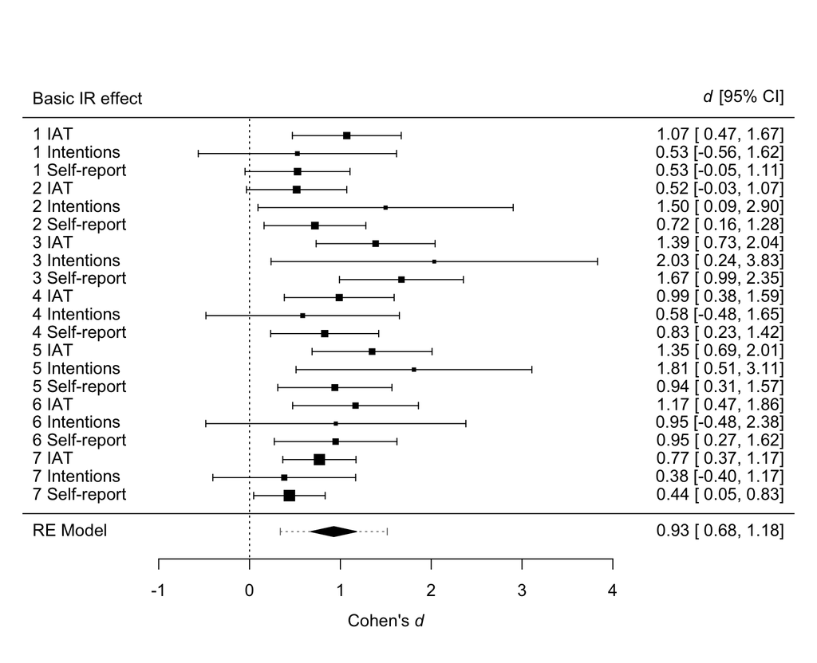

```r
results_for_meta_basic_IR_effect_iat_selfreports <- results_basic_effect_iat_selfreports %>%
  rename(yi = cohens_d) %>%
  mutate(sei = (cohens_d_ci_upper - cohens_d_ci_lower)/(2*1.96)) %>%
  select(experiment, DV_type, yi, sei) %>%
  filter(DV_type %in% c("IAT_D2", "self_reported_IR_effect"))

results_for_meta_basic_effect_intentions_ir <- data_reshaped_intentions_acquisition_ir %>%
  pivot_wider(names_from = stimulus_identity_condition,
              values_from = c(brand_A, brand_B)) %>%
  escalc(measure = "OR",
         ai = brand_A_Outcome_1_Target_1_Good_Outcome_2_Target_2_Bad,
         bi = brand_B_Outcome_1_Target_1_Good_Outcome_2_Target_2_Bad,
         ci = brand_A_Outcome_1_Target_1_Bad_Outcome_2_Target_2_Good,
         di = brand_B_Outcome_1_Target_1_Bad_Outcome_2_Target_2_Good,
         data = .) %>%
  mutate(sei = sqrt(logOR_to_d(vi)),
         yi = logOR_to_d(yi),
         DV_type = "Intentions") %>%
  select(experiment, DV_type, yi, sei)

fit_basic_effect_ir <-
  bind_rows(results_for_meta_basic_IR_effect_iat_selfreports,
            results_for_meta_basic_effect_intentions_ir) %>%
  mutate(DV_type = dplyr::recode(DV_type,
                                 "IAT_D2" = "IAT",
                                 "self_reported_IR_effect" = "Self-report",
                                 "Intentions" = "Intentions")) %>%
  arrange(experiment, DV_type) %>%
  rma.mv(yi      = yi,
         V       = sei^2,
         random  = ~ DV_type | experiment,
         data    = .,
         slab    = paste(experiment, DV_type))

forest(fit_basic_effect_ir,
       xlab = substitute(paste("Cohen's ", italic('d'))),
       addcred = TRUE,
       refline = 0,
       xlim = c(-2.5, 6),
       at = c(-1, 0, 1, 2, 3, 4))
text(-2.5, 23, "Basic IR effect", pos = 4)
text(6, 23, substitute(paste(italic('d'), " [95% CI]")), pos = 2)
```

```r
# save model fits for making pdf plots for publication
write_rds(fit_basic_effect_ir, "models/fit_basic_effect_ir.rds")
```

meta p value: 3.923924810^{-13}

## Basic OEC effect

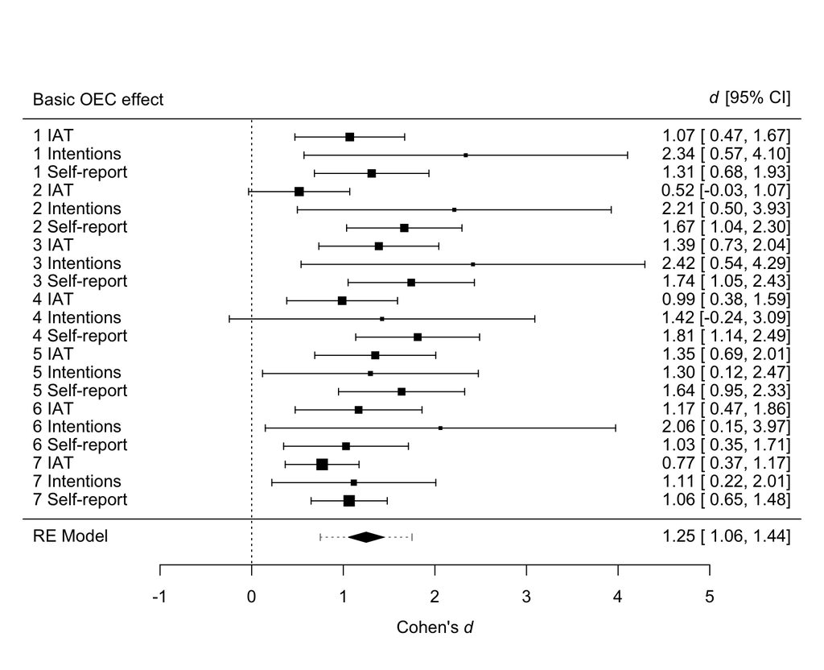

```r
results_for_meta_basic_OEC_effect_iat_selfreports <- results_basic_effect_iat_selfreports %>%
  rename(yi = cohens_d) %>%
  mutate(sei = (cohens_d_ci_upper - cohens_d_ci_lower)/(2*1.96)) %>%
  select(experiment, DV_type, yi, sei) %>%
  filter(DV_type %in% c("IAT_D2", "self_reported_OEC_effect"))

results_for_meta_basic_effect_intentions_oec <- data_reshaped_intentions_acquisition_oec %>%
  pivot_wider(names_from = stimulus_identity_condition,
              values_from = c(brand_A, brand_B)) %>%
  escalc(measure = "OR",
         ai = brand_A_Outcome_1_Target_1_Good_Outcome_2_Target_2_Bad,
         bi = brand_B_Outcome_1_Target_1_Good_Outcome_2_Target_2_Bad,
         ci = brand_A_Outcome_1_Target_1_Bad_Outcome_2_Target_2_Good,
         di = brand_B_Outcome_1_Target_1_Bad_Outcome_2_Target_2_Good,
         data = .) %>%
  mutate(sei = sqrt(logOR_to_d(vi)),
         yi = logOR_to_d(yi),
         DV_type = "Intentions") %>%
  select(experiment, DV_type, yi, sei)

fit_basic_effect_oec <-
  bind_rows(results_for_meta_basic_OEC_effect_iat_selfreports,
            results_for_meta_basic_effect_intentions_oec) %>%
  mutate(DV_type = dplyr::recode(DV_type,
                                 "IAT_D2" = "IAT",
                                 "self_reported_OEC_effect" = "Self-report",
                                 "Intentions" = "Intentions")) %>%
  arrange(experiment, DV_type) %>%
  rma.mv(yi      = yi,
         V       = sei^2,
         random  = ~ DV_type | experiment,
         data    = .,
         slab    = paste(experiment, DV_type))

forest(fit_basic_effect_oec,
       xlab = substitute(paste("Cohen's ", italic('d'))),
       addcred = TRUE,
       refline = 0,
       xlim = c(-2.5, 6),
       at = c(-1, 0, 1, 2, 3, 4, 5))
text(-2.5, 23, "Basic OEC effect", pos = 4)
text(6, 23, substitute(paste(italic('d'), " [95% CI]")), pos = 2)
```

```r
# save model fits for making pdf plots for publication
write_rds(fit_basic_effect_oec, "models/fit_basic_effect_oec.rds")
```

meta p value: 1.81923910^{-37}

## Moderation by extinction

### IR effect

multilevel meta

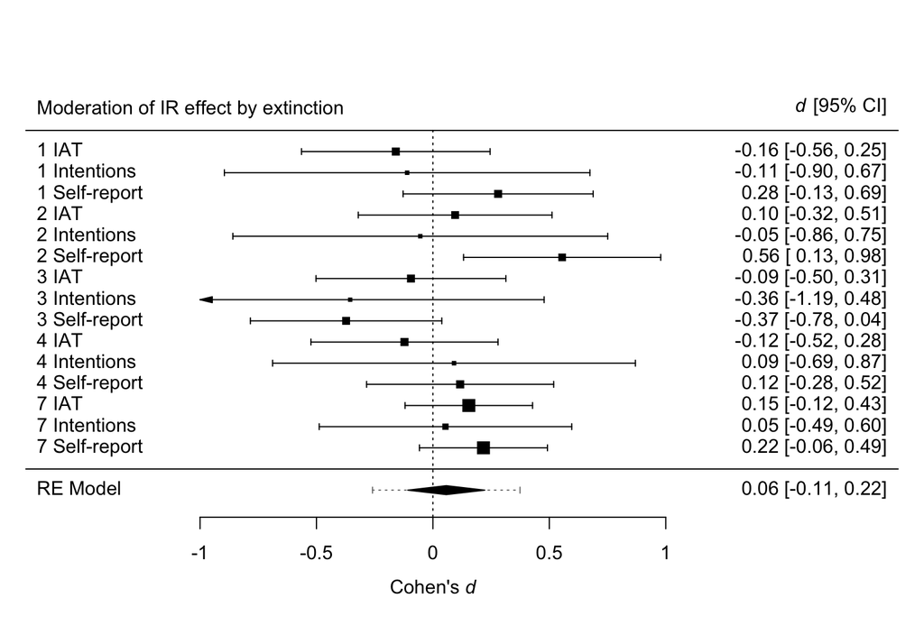

```r
results_for_meta_extinction_ir <- results_moderation_by_extinction %>%
  rename(yi = cohens_d) %>%
  mutate(sei = (cohens_d_ci_upper - cohens_d_ci_lower)/(2*1.96)) %>%
  select(experiment, DV_type, yi, sei) %>%
  filter(DV_type %in% c("IAT_D2_controlling_stimulus_identity", "self_reported_IR_effect_controlling_stimulus_identity"))

results_for_meta_moderation_extinction_intentions_ir <- data_reshaped_intentions_moderation_by_extinction_ir %>%
  pivot_wider(names_from = experiment_condition,
              values_from = c(brand_A, brand_B)) %>%
  escalc(measure = "OR",
         ai = brand_A_acquisition_only,
         bi = brand_B_acquisition_only,
         ci = brand_A_acquisition_and_extinction,
         di = brand_B_acquisition_and_extinction,
         data = .) %>%
  mutate(sei = sqrt(logOR_to_d(vi)),
         yi = logOR_to_d(yi),
         DV_type = "Intentions") %>%
  select(experiment, DV_type, yi, sei)

fit_moderation_by_extinction_ir <-
  bind_rows(results_for_meta_extinction_ir,
            results_for_meta_moderation_extinction_intentions_ir) %>%
  mutate(DV_type = dplyr::recode(DV_type,
                                 "IAT_D2_controlling_stimulus_identity" = "IAT",
                                 "self_reported_IR_effect_controlling_stimulus_identity" = "Self-report",
                                 "Intentions" = "Intentions")) %>%
  arrange(experiment, DV_type) %>%
  rma.mv(yi      = yi,
         V       = sei^2,
         random  = ~ DV_type | experiment,
         data    = .,
         slab    = paste(experiment, DV_type))

forest(fit_moderation_by_extinction_ir,
       xlab = substitute(paste("Cohen's ", italic('d'))),
       addcred = TRUE,
       refline = 0,
       xlim = c(-1.75, 2),
       at = c(-1, -0.5, 0, 0.5, 1))
text(-1.75, 17, "Moderation of IR effect by extinction", pos = 4)
text(2, 17, substitute(paste(italic('d'), " [95% CI]")), pos = 2)
```

```r
# save model fits for making pdf plots for publication
write_rds(fit_moderation_by_extinction_ir, "models/fit_moderation_by_extinction_ir.rds")
```

meta p value: 0.4959828

### OEC effect

multilevel meta

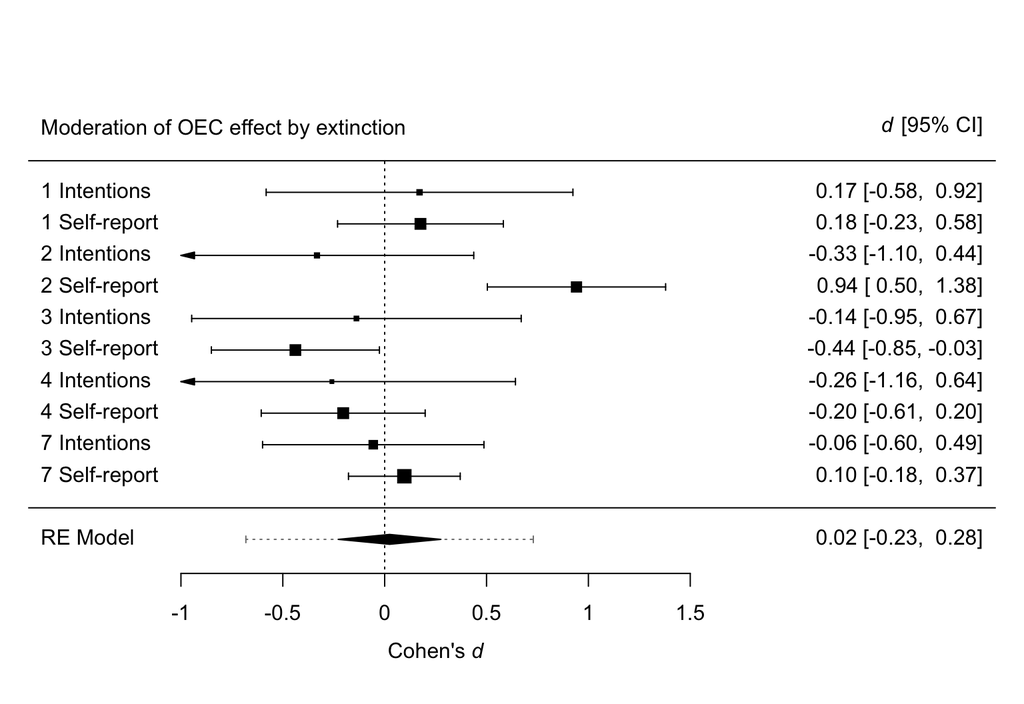

```r
results_for_meta_extinction_oec <- results_moderation_by_extinction %>%
  rename(yi = cohens_d) %>%
  mutate(sei = (cohens_d_ci_upper - cohens_d_ci_lower)/(2*1.96)) %>%
  select(experiment, DV_type, yi, sei) %>%
  filter(DV_type %in% c("self_reported_OEC_effect_controlling_stimulus_identity"))

results_for_meta_moderation_extinction_intentions_oec <- data_reshaped_intentions_moderation_by_extinction_oec %>%
  pivot_wider(names_from = experiment_condition,
              values_from = c(brand_A, brand_B)) %>%
  escalc(measure = "OR",
         ai = brand_A_acquisition_only,
         bi = brand_B_acquisition_only,
         ci = brand_A_acquisition_and_extinction,
         di = brand_B_acquisition_and_extinction,
         data = .) %>%
  mutate(sei = sqrt(logOR_to_d(vi)),
         yi = logOR_to_d(yi),
         DV_type = "Intentions") %>%
  select(experiment, DV_type, yi, sei)

fit_moderation_by_extinction_oec <-
  bind_rows(results_for_meta_extinction_oec,
            results_for_meta_moderation_extinction_intentions_oec) %>%
  mutate(DV_type = dplyr::recode(DV_type,
                                 "self_reported_OEC_effect_controlling_stimulus_identity" = "Self-report",
                                 "Intentions" = "Intentions")) %>%
  arrange(experiment, DV_type) %>%
  rma.mv(yi      = yi,
         V       = sei^2,
         random  = ~ DV_type | experiment,
         data    = .,
         slab    = paste(experiment, DV_type))

forest(fit_moderation_by_extinction_oec,
       xlab = substitute(paste("Cohen's ", italic('d'))),
       addcred = TRUE,
       refline = 0,
       xlim = c(-1.75, 3),
       at = c(-1, -0.5, 0, 0.5, 1, 1.5))
text(-1.75, 12, "Moderation of OEC effect by extinction", pos = 4)
text(3, 12, substitute(paste(italic('d'), " [95% CI]")), pos = 2)
```

```r
# save model fits for making pdf plots for publication
write_rds(fit_moderation_by_extinction_oec, "models/fit_moderation_by_extinction_oec.rds")
```

meta p value: 0.851027

## Moderation by counter conditioning

### IR effect

multilevel meta

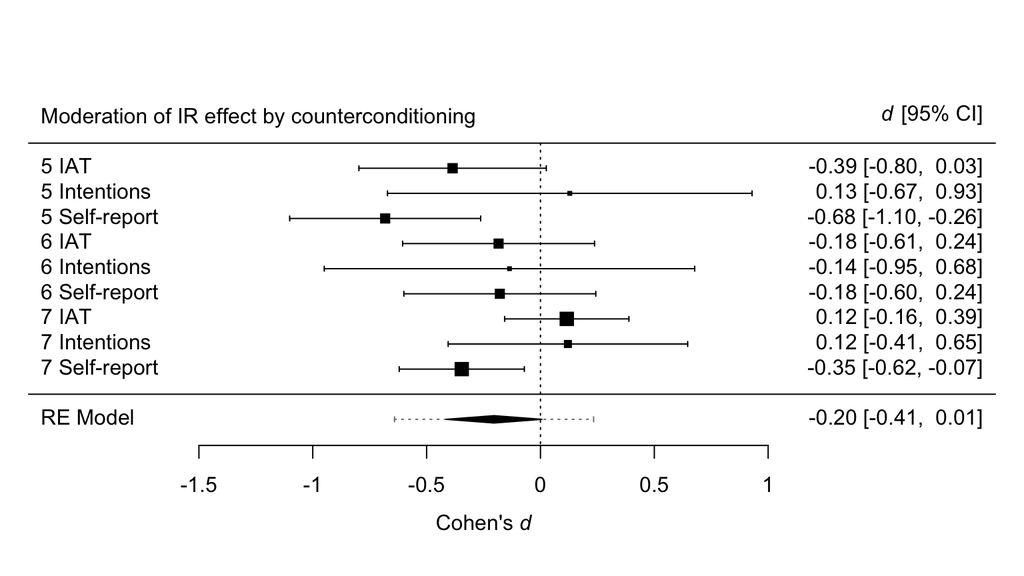

```r
results_for_meta_counterconditioning_ir <- results_moderation_by_counterconditioning %>%
  rename(yi = cohens_d) %>%
  mutate(sei = (cohens_d_ci_upper - cohens_d_ci_lower)/(2*1.96)) %>%
  select(experiment, DV_type, yi, sei) %>%
  filter(DV_type %in% c("IAT_D2_controlling_stimulus_identity", "self_reported_IR_effect_controlling_stimulus_identity"))

results_for_meta_moderation_counterconditioning_intentions_ir <- data_reshaped_intentions_moderation_by_counterconditioning_ir %>%
  pivot_wider(names_from = experiment_condition,
              values_from = c(brand_A, brand_B)) %>%
  escalc(measure = "OR",
         ai = brand_A_acquisition_only,
         bi = brand_B_acquisition_only,
         ci = brand_A_acquisition_and_counterconditioning,
         di = brand_B_acquisition_and_counterconditioning,
         data = .) %>%
  mutate(sei = sqrt(logOR_to_d(vi)),
         yi = logOR_to_d(yi),
         DV_type = "Intentions") %>%
  select(experiment, DV_type, yi, sei)

fit_moderation_by_counterconditioning_ir <-
  bind_rows(results_for_meta_counterconditioning_ir,
            results_for_meta_moderation_counterconditioning_intentions_ir) %>%
  mutate(DV_type = dplyr::recode(DV_type,
                                 "IAT_D2_controlling_stimulus_identity" = "IAT",
                                 "self_reported_IR_effect_controlling_stimulus_identity" = "Self-report",
                                 "Intentions" = "Intentions")) %>%
  arrange(experiment, DV_type) %>%
  arrange(experiment, DV_type) %>%
  rma.mv(yi      = yi,
         V       = sei^2,
         random  = ~ DV_type | experiment,
         data    = .,
         slab    = paste(experiment, DV_type))

forest(fit_moderation_by_counterconditioning_ir,
       xlab = substitute(paste("Cohen's ", italic('d'))),
       addcred = TRUE,
       refline = 0,
       xlim = c(-2.25, 2),
       at = c(-1.5, -1, -0.5, 0, 0.5, 1))
text(-2.25, 11, "Moderation of IR effect by counterconditioning", pos = 4)
text(2, 11, substitute(paste(italic('d'), " [95% CI]")), pos = 2)
```

```r
# save model fits for making pdf plots for publication
write_rds(fit_moderation_by_counterconditioning_ir, "models/fit_moderation_by_counterconditioning_ir.rds")
```

meta p value: 0.0571246

### OEC effect

multilevel meta

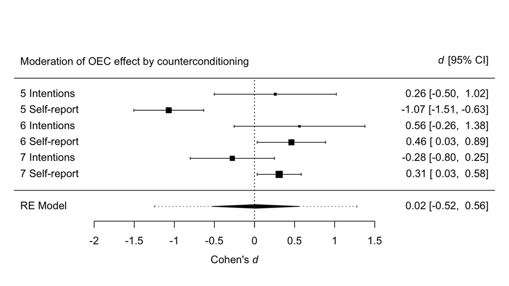

```r
results_for_meta_counterconditioning_oec <- results_moderation_by_counterconditioning %>%
  rename(yi = cohens_d) %>%
  mutate(sei = (cohens_d_ci_upper - cohens_d_ci_lower)/(2*1.96)) %>%
  select(experiment, DV_type, yi, sei) %>%
  filter(DV_type %in% c("self_reported_OEC_effect_controlling_stimulus_identity"))

results_for_meta_moderation_counterconditioning_intentions_oec <- data_reshaped_intentions_moderation_by_counterconditioning_oec %>%
  pivot_wider(names_from = experiment_condition,
              values_from = c(brand_A, brand_B)) %>%
  escalc(measure = "OR",
         ai = brand_A_acquisition_only,
         bi = brand_B_acquisition_only,
         ci = brand_A_acquisition_and_counterconditioning,
         di = brand_B_acquisition_and_counterconditioning,
         data = .) %>%
  mutate(sei = sqrt(logOR_to_d(vi)),
         yi = logOR_to_d(yi),
         DV_type = "Intentions") %>%
  select(experiment, DV_type, yi, sei)

fit_moderation_by_counterconditioning_oec <-
  bind_rows(results_for_meta_counterconditioning_oec,
            results_for_meta_moderation_counterconditioning_intentions_oec) %>%
  mutate(DV_type = dplyr::recode(DV_type,
                                 "self_reported_OEC_effect_controlling_stimulus_identity" = "Self-report",
                                 "Intentions" = "Intentions")) %>%
  arrange(experiment, DV_type) %>%
  arrange(experiment, DV_type) %>%
  rma.mv(yi      = yi,
         V       = sei^2,
         random  = ~ DV_type | experiment,
         data    = .,
         slab    = paste(experiment, DV_type))

forest(fit_moderation_by_counterconditioning_oec,
       xlab = substitute(paste("Cohen's ", italic('d'))),
       addcred = TRUE,
       refline = 0,
       xlim = c(-3, 3),
       at = c(-2, -1.5, -1, -0.5, 0, 0.5, 1, 1.5))
text(-3, 8, "Moderation of OEC effect by counterconditioning", pos = 4)
text(3, 8, substitute(paste(italic('d'), " [95% CI]")), pos = 2)
```

```r
# save model fits for making pdf plots for publication
write_rds(fit_moderation_by_counterconditioning_oec, "models/fit_moderation_by_counterconditioning_oec.rds")
```

meta p value: 0.9547071

# Sensitivity meta-analyses

Also excluded participants who failed to meet mastery criteria in training or testing phases. Question is considered only at the level of meta-analyses, as sample sizes likely to be under powered at study level.

## Sample sizes

```r
data_processed_after_exclusions_sensitivity <- data_processed_after_exclusions %>%
  filter(passed_performance_criterion_acquisition_training == TRUE &
           passed_performance_criterion_acquisition_testing == TRUE)

data_processed_after_exclusions %>%
  mutate(training_and_testing_exclusions = ifelse(passed_performance_criterion_acquisition_training == TRUE &
                                                    passed_performance_criterion_acquisition_testing == TRUE,
                                                  FALSE, TRUE)) %>%
  summarize(original_n = n(),
            excluded_n = sum(training_and_testing_exclusions),
            excluded_percent = mean(training_and_testing_exclusions*100)) %>%
  mutate_if(is.numeric, round, digits = 1) %>%
  kable(align = "c") %>%
  kable_styling(bootstrap_options = c("striped", "hover", "condensed"), full_width = FALSE)
```

| original_n | excluded_n | excluded_percent |
| --- | --- | --- |
| 882 | 201 | 22.8 |

```r
data_processed_after_exclusions %>%
  mutate(training_and_testing_exclusions = ifelse(passed_performance_criterion_acquisition_training == TRUE &
                                                    passed_performance_criterion_acquisition_testing == TRUE,
                                                  FALSE, TRUE)) %>%
  group_by(experiment) %>%
  summarize(original_n = n(),
            excluded_n = sum(training_and_testing_exclusions),
            excluded_percent = mean(training_and_testing_exclusions*100)) %>%
  mutate_if(is.numeric, round, digits = 1) %>%
  kable(align = "c") %>%
  kable_styling(bootstrap_options = c("striped", "hover", "condensed"), full_width = FALSE)
```

| experiment | original_n | excluded_n | excluded_percent |
| --- | --- | --- | --- |
| 1 | 97 | 22 | 22.7 |
| 2 | 94 | 15 | 16.0 |
| 3 | 95 | 23 | 24.2 |
| 4 | 98 | 20 | 20.4 |
| 5 | 95 | 17 | 17.9 |
| 6 | 90 | 12 | 13.3 |
| 7 | 313 | 92 | 29.4 |

## Basic effect

### IR

multilevel meta

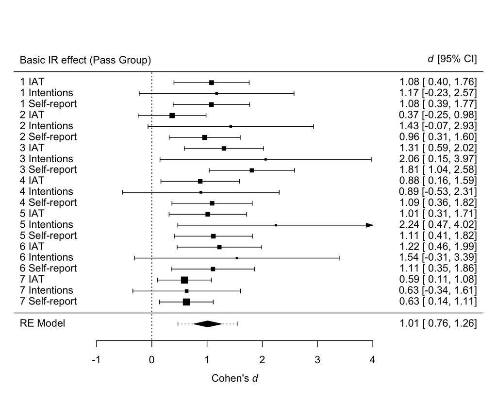

```r
results_for_meta_basic_effect_iat_selfreports_ir_sensitivity <- data_processed_after_exclusions_sensitivity %>%
  filter(experiment_condition == "acquisition_only") %>%
  rename(IV = stimulus_identity_condition) %>%
  gather(DV_type, DV, c(self_reported_IR_effect, IAT_D2)) %>%
  select(experiment, DV_type, DV, IV) %>%
  drop_na() %>%
  analysis_workflow(data = .) %>%
  rename(yi = cohens_d) %>%
  mutate(sei = (cohens_d_ci_upper - cohens_d_ci_lower)/(2*1.96)) %>%
  select(experiment, DV_type, yi, sei) %>%
  filter(DV_type %in% c("IAT_D2", "self_reported_IR_effect"))

results_basic_effect_intentions_ir_sensitivity <- data_processed_after_exclusions_sensitivity %>%
  filter(experiment_condition == c("acquisition_only") &
           behavioral_intentions_IR %in% c("brand_A", "brand_B")) %>%
  count(experiment, stimulus_identity_condition, behavioral_intentions_IR) %>%
  spread(behavioral_intentions_IR, n) %>%
  # Haldane-Anscombe correction
  group_by(experiment) %>%
  mutate(count_zero = as.logical(max(c(is.na(brand_A), is.na(brand_B))))) %>%
  ungroup() %>%
  mutate(brand_A = ifelse(count_zero, brand_A+1, brand_A),
         brand_A = ifelse(is.na(brand_A), 1, brand_A),
         brand_B = ifelse(count_zero, brand_B+1, brand_B),
         brand_B = ifelse(is.na(brand_B), 1, brand_B)) %>%
  select(experiment, stimulus_identity_condition, brand_A, brand_B) %>%
  pivot_wider(names_from = stimulus_identity_condition,
              values_from = c(brand_A, brand_B)) %>%
  escalc(measure = "OR",
         ai = brand_A_Outcome_1_Target_1_Good_Outcome_2_Target_2_Bad,
         bi = brand_B_Outcome_1_Target_1_Good_Outcome_2_Target_2_Bad,
         ci = brand_A_Outcome_1_Target_1_Bad_Outcome_2_Target_2_Good,
         di = brand_B_Outcome_1_Target_1_Bad_Outcome_2_Target_2_Good,
         data = .) %>%
  mutate(sei = sqrt(logOR_to_d(vi)),
         yi = logOR_to_d(yi),
         DV_type = "Intentions") %>%
  select(experiment, DV_type, yi, sei)

fit_basic_effect_ir_sensitivity <-
  bind_rows(results_for_meta_basic_effect_iat_selfreports_ir_sensitivity,
            results_basic_effect_intentions_ir_sensitivity) %>%
  mutate(DV_type = dplyr::recode(DV_type,
                                 "IAT_D2" = "IAT",
                                 "self_reported_IR_effect" = "Self-report",
                                 "Intentions" = "Intentions")) %>%
  arrange(experiment, DV_type) %>%
  rma.mv(yi      = yi,
         V       = sei^2,
         random  = ~ DV_type | experiment,
         data    = .,
         slab    = paste(experiment, DV_type))

forest(fit_basic_effect_ir_sensitivity,
       xlab = substitute(paste("Cohen's ", italic('d'))),
       addcred = TRUE,
       refline = 0,
       xlim = c(-2.5, 6),
       at = c(-1, 0, 1, 2, 3, 4))
text(-2.5, 23, "Basic IR effect (Pass Group)", pos = 4)
text(6, 23, substitute(paste(italic('d'), " [95% CI]")), pos = 2)
```

```r
# save model fits for making pdf plots for publication
write_rds(fit_basic_effect_ir_sensitivity, "models/fit_basic_effect_ir_sensitivity.rds")

congruence_with_full_sample_ir <-
  ifelse((fit_basic_effect_ir$ci.lb > 0 & fit_basic_effect_ir_sensitivity$ci.lb > 0) |
           (fit_basic_effect_ir$ci.ub < 0 & fit_basic_effect_ir_sensitivity$ci.ub < 0) |
           (fit_basic_effect_ir$ci.lb < 0 & fit_basic_effect_ir_sensitivity$ci.lb < 0 &
              fit_basic_effect_ir$ci.ub > 0 & fit_basic_effect_ir_sensitivity$ci.ub > 0),
         "Conclusions about the signficance of the estimate of the effect were congruent between the meta-analysis and sensitivity analysis.", "Conclusions about the signficance of the estimate of the effect were incongruent between the meta-analysis and sensitivity analysis.")
```

Conclusions about the signficance of the estimate of the effect were congruent between the meta-analysis and sensitivity analysis.

### OEC

multilevel meta

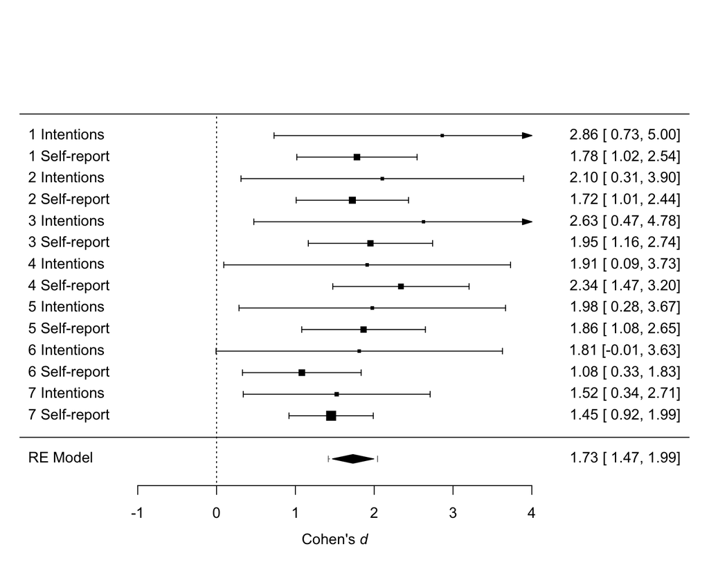

```r
results_for_meta_basic_effect_iat_selfreports_oec_sensitivity <- data_processed_after_exclusions_sensitivity %>%
  filter(experiment_condition == "acquisition_only") %>%
  rename(IV = stimulus_identity_condition) %>%
  gather(DV_type, DV, c(self_reported_OEC_effect)) %>%
  select(experiment, DV_type, DV, IV) %>%
  drop_na() %>%
  analysis_workflow(data = .) %>%
  rename(yi = cohens_d) %>%
  mutate(sei = (cohens_d_ci_upper - cohens_d_ci_lower)/(2*1.96)) %>%
  select(experiment, DV_type, yi, sei) %>%
  filter(DV_type %in% c("self_reported_OEC_effect"))

results_basic_effect_intentions_oec_sensitivity <- data_processed_after_exclusions_sensitivity %>%
  filter(experiment_condition == c("acquisition_only") &
           behavioral_intentions_OEC %in% c("brand_A", "brand_B")) %>%
  count(experiment, stimulus_identity_condition, behavioral_intentions_OEC) %>%
  spread(behavioral_intentions_OEC, n) %>%
  # Haldane-Anscombe correction
  group_by(experiment) %>%
  mutate(count_zero = as.logical(max(c(is.na(brand_A), is.na(brand_B))))) %>%
  ungroup() %>%
  mutate(brand_A = ifelse(count_zero, brand_A+1, brand_A),
         brand_A = ifelse(is.na(brand_A), 1, brand_A),
         brand_B = ifelse(count_zero, brand_B+1, brand_B),
         brand_B = ifelse(is.na(brand_B), 1, brand_B)) %>%
  select(experiment, stimulus_identity_condition, brand_A, brand_B) %>%
  pivot_wider(names_from = stimulus_identity_condition,
              values_from = c(brand_A, brand_B)) %>%
  escalc(measure = "OR",
         ai = brand_A_Outcome_1_Target_1_Good_Outcome_2_Target_2_Bad,
         bi = brand_B_Outcome_1_Target_1_Good_Outcome_2_Target_2_Bad,
         ci = brand_A_Outcome_1_Target_1_Bad_Outcome_2_Target_2_Good,
         di = brand_B_Outcome_1_Target_1_Bad_Outcome_2_Target_2_Good,
         data = .) %>%
  mutate(sei = sqrt(logOR_to_d(vi)),
         yi = logOR_to_d(yi),
         DV_type = "Intentions") %>%
  select(experiment, DV_type, yi, sei)

fit_basic_effect_oec_sensitivity <-
  bind_rows(results_for_meta_basic_effect_iat_selfreports_oec_sensitivity,
            results_basic_effect_intentions_oec_sensitivity) %>%
  mutate(DV_type = dplyr::recode(DV_type,
                                 "self_reported_OEC_effect" = "Self-report",
                                 "Intentions" = "Intentions")) %>%
  arrange(experiment, DV_type) %>%
  rma.mv(yi      = yi,
         V       = sei^2,
         random  = ~ DV_type | experiment,
         data    = .,
         slab    = paste(experiment, DV_type))

forest(fit_basic_effect_oec_sensitivity,
       xlab = substitute(paste("Cohen's ", italic('d'))),
       addcred = TRUE,
       refline = 0,
       xlim = c(-2.5, 6),
       at = c(-1, 0, 1, 2, 3, 4))
text(-2.5, 23, "Basic OEC effect (Pass Group)", pos = 4)
text(6, 23, substitute(paste(italic('d'), " [95% CI]")), pos = 2)
```

```r
# save model fits for making pdf plots for publication
write_rds(fit_basic_effect_oec_sensitivity, "models/fit_basic_effect_oec_sensitivity.rds")

congruence_with_full_sample_oec <-
  ifelse((fit_basic_effect_oec$ci.lb > 0 & fit_basic_effect_oec_sensitivity$ci.lb > 0) |
           (fit_basic_effect_oec$ci.ub < 0 & fit_basic_effect_oec_sensitivity$ci.ub < 0) |
           (fit_basic_effect_oec$ci.lb < 0 & fit_basic_effect_oec_sensitivity$ci.lb < 0 &
              fit_basic_effect_oec$ci.ub > 0 & fit_basic_effect_oec_sensitivity$ci.ub > 0),
         "Conclusions about the signficance of the estimate of the effect were congruent between the meta-analysis and sensitivity analysis.", "Conclusions about the signficance of the estimate of the effect were incongruent between the meta-analysis and sensitivity analysis.")
```

Conclusions about the signficance of the estimate of the effect were congruent between the meta-analysis and sensitivity analysis.

## Moderation by extinction

### IR

multilevel meta

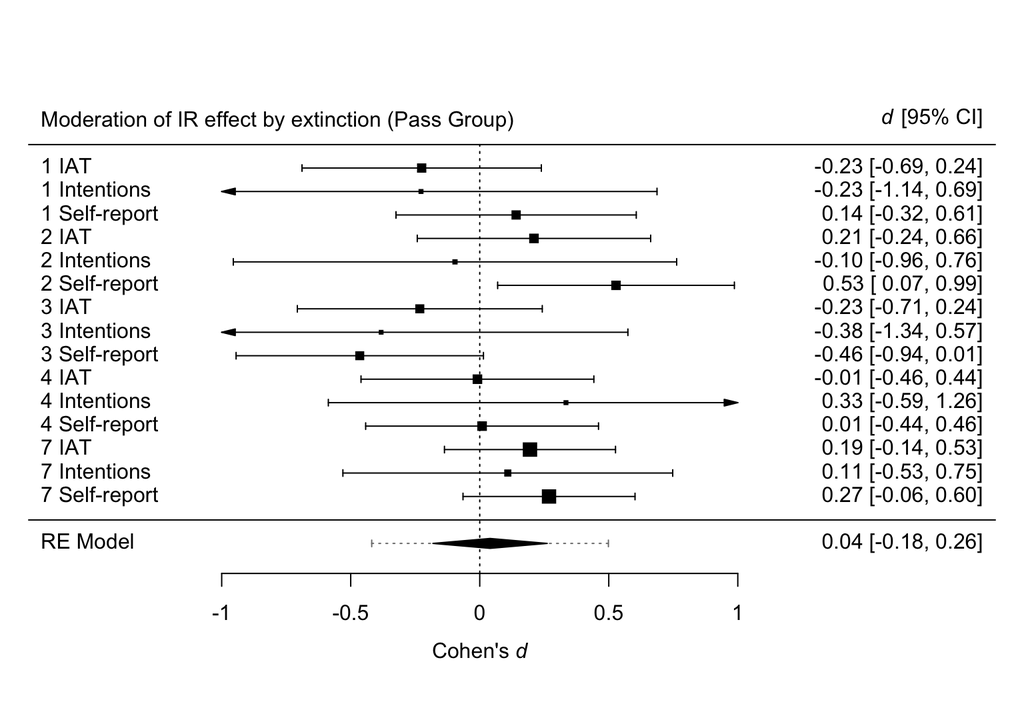

```r
results_for_meta_extinction_ir_sensitivity <- data_processed_after_exclusions_sensitivity %>%
  filter(experiment_condition %in% c("acquisition_only", "acquisition_and_extinction") &
           experiment %in% c(1, 2, 3, 4, 7)) %>%
  rename(IV = experiment_condition) %>%
  mutate(IV = fct_relevel(IV, "acquisition_and_extinction", "acquisition_only")) %>%
  gather(DV_type, DV, c(self_reported_IR_effect_controlling_stimulus_identity,
                        IAT_D2_controlling_stimulus_identity)) %>%
  select(experiment, DV_type, DV, IV) %>%
  drop_na() %>%
  analysis_workflow(data = .) %>%
  rename(yi = cohens_d) %>%
  mutate(sei = (cohens_d_ci_upper - cohens_d_ci_lower)/(2*1.96)) %>%
  select(experiment, DV_type, yi, sei) %>%
  filter(DV_type %in% c("IAT_D2_controlling_stimulus_identity", "self_reported_IR_effect_controlling_stimulus_identity"))

results_moderation_extinction_intentions_ir_sensitivity <- data_processed_after_exclusions_sensitivity %>%
  filter(experiment_condition %in% c("acquisition_only", "acquisition_and_extinction") &
           experiment %in% c(1, 2, 3, 4, 7) &
           behavioral_intentions_IR %in% c("brand_A", "brand_B")) %>%
  count(experiment, experiment_condition, behavioral_intentions_IR) %>%
  spread(behavioral_intentions_IR, n) %>%
  # Haldane-Anscombe correction
  group_by(experiment) %>%
  mutate(count_zero = as.logical(max(c(is.na(brand_A), is.na(brand_B))))) %>%
  ungroup() %>%
  mutate(brand_A = ifelse(count_zero, brand_A+1, brand_A),
         brand_A = ifelse(is.na(brand_A), 1, brand_A),
         brand_B = ifelse(count_zero, brand_B+1, brand_B),
         brand_B = ifelse(is.na(brand_B), 1, brand_B)) %>%
  select(experiment, experiment_condition, brand_A, brand_B) %>%
  pivot_wider(names_from = experiment_condition,
              values_from = c(brand_A, brand_B)) %>%
  escalc(measure = "OR",
         ai = brand_A_acquisition_only,
         bi = brand_B_acquisition_only,
         ci = brand_A_acquisition_and_extinction,
         di = brand_B_acquisition_and_extinction,
         data = .) %>%
  mutate(sei = sqrt(logOR_to_d(vi)),
         yi = logOR_to_d(yi),
         DV_type = "Intentions") %>%
  select(experiment, DV_type, yi, sei)

fit_moderation_by_extinction_ir_sensitivity <-
  bind_rows(results_for_meta_extinction_ir_sensitivity,
            results_moderation_extinction_intentions_ir_sensitivity) %>%
  mutate(DV_type = dplyr::recode(DV_type,
                                 "IAT_D2_controlling_stimulus_identity" = "IAT",
                                 "self_reported_IR_effect_controlling_stimulus_identity" = "Self-report",
                                 "Intentions" = "Intentions")) %>%
  arrange(experiment, DV_type) %>%
  rma.mv(yi      = yi,
         V       = sei^2,
         random  = ~ DV_type | experiment,
         data    = .,
         slab    = paste(experiment, DV_type))

forest(fit_moderation_by_extinction_ir_sensitivity,
       xlab = substitute(paste("Cohen's ", italic('d'))),
       addcred = TRUE,
       refline = 0,
       xlim = c(-1.75, 2),
       at = c(-1, -0.5, 0, 0.5, 1))
text(-1.75, 17, "Moderation of IR effect by extinction (Pass Group)", pos = 4)
text(2, 17, substitute(paste(italic('d'), " [95% CI]")), pos = 2)
```

```r
# save model fits for making pdf plots for publication
write_rds(fit_moderation_by_extinction_ir_sensitivity, "models/fit_moderation_by_extinction_ir_sensitivity.rds")

congruence_with_full_sample_extinction_ir <-
  ifelse((fit_moderation_by_extinction_ir$ci.lb > 0 & fit_moderation_by_extinction_ir_sensitivity$ci.lb > 0) |
           (fit_moderation_by_extinction_ir$ci.ub < 0 & fit_moderation_by_extinction_ir_sensitivity$ci.ub < 0) |
           (fit_moderation_by_extinction_ir$ci.lb < 0 & fit_moderation_by_extinction_ir_sensitivity$ci.lb < 0 &
              fit_moderation_by_extinction_ir$ci.ub > 0 & fit_moderation_by_extinction_ir_sensitivity$ci.ub > 0),
         "Conclusions about the signficance of the estimate of the effect were congruent between the meta-analysis and sensitivity analysis.", "Conclusions about the signficance of the estimate of the effect were incongruent between the meta-analysis and sensitivity analysis.")
```

Conclusions about the signficance of the estimate of the effect were congruent between the meta-analysis and sensitivity analysis.

### OEC

multilevel meta

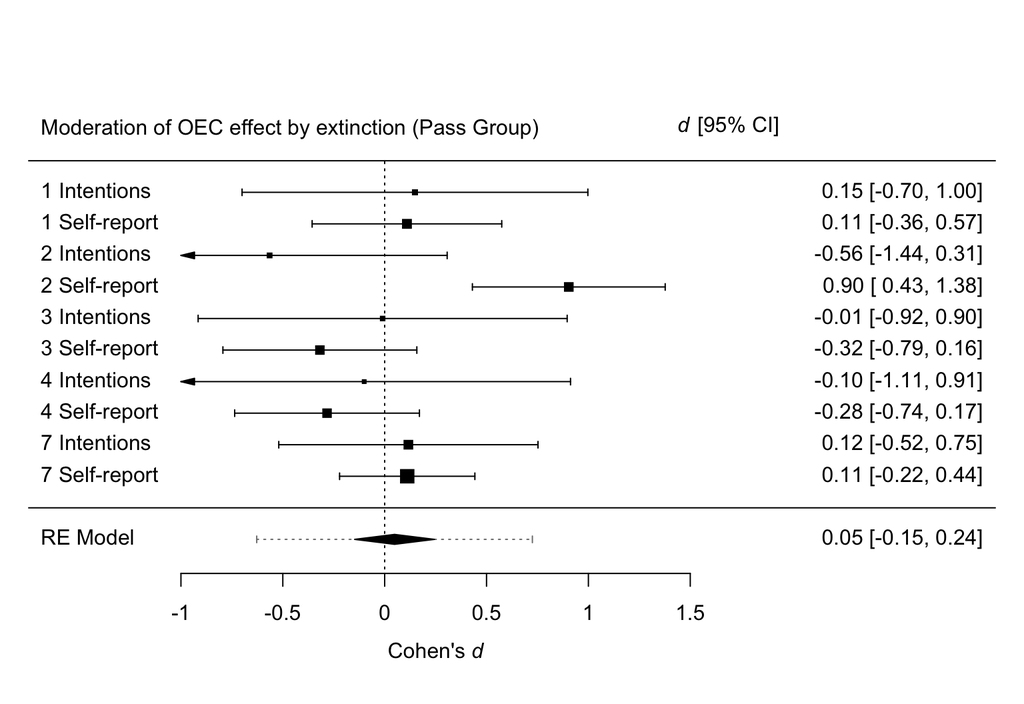

```r
results_for_meta_extinction_oec_sensitivity <- data_processed_after_exclusions_sensitivity %>%
  filter(experiment_condition %in% c("acquisition_only", "acquisition_and_extinction") &
           experiment %in% c(1, 2, 3, 4, 7)) %>%
  rename(IV = experiment_condition) %>%
  mutate(IV = fct_relevel(IV, "acquisition_and_extinction", "acquisition_only")) %>%
  gather(DV_type, DV, c(self_reported_OEC_effect_controlling_stimulus_identity)) %>%
  select(experiment, DV_type, DV, IV) %>%
  drop_na() %>%
  analysis_workflow(data = .) %>%
  rename(yi = cohens_d) %>%
  mutate(sei = (cohens_d_ci_upper - cohens_d_ci_lower)/(2*1.96)) %>%
  select(experiment, DV_type, yi, sei) %>%
  filter(DV_type %in% c("self_reported_OEC_effect_controlling_stimulus_identity"))

results_moderation_extinction_intentions_oec_sensitivity <- data_processed_after_exclusions_sensitivity %>%
  filter(experiment_condition %in% c("acquisition_only", "acquisition_and_extinction") &
           experiment %in% c(1, 2, 3, 4, 7) &
           behavioral_intentions_OEC %in% c("brand_A", "brand_B")) %>%
  count(experiment, experiment_condition, behavioral_intentions_OEC) %>%
  spread(behavioral_intentions_OEC, n) %>%
  # Haldane-Anscombe correction
  group_by(experiment) %>%
  mutate(count_zero = as.logical(max(c(is.na(brand_A), is.na(brand_B))))) %>%
  ungroup() %>%
  mutate(brand_A = ifelse(count_zero, brand_A+1, brand_A),
         brand_A = ifelse(is.na(brand_A), 1, brand_A),
         brand_B = ifelse(count_zero, brand_B+1, brand_B),
         brand_B = ifelse(is.na(brand_B), 1, brand_B)) %>%
  select(experiment, experiment_condition, brand_A, brand_B) %>%
  pivot_wider(names_from = experiment_condition,
              values_from = c(brand_A, brand_B)) %>%
  escalc(measure = "OR",
         ai = brand_A_acquisition_only,
         bi = brand_B_acquisition_only,
         ci = brand_A_acquisition_and_extinction,
         di = brand_B_acquisition_and_extinction,
         data = .) %>%
  mutate(sei = sqrt(logOR_to_d(vi)),
         yi = logOR_to_d(yi),
         DV_type = "Intentions") %>%
  select(experiment, DV_type, yi, sei)

fit_moderation_by_extinction_oec_sensitivity <-
  bind_rows(results_for_meta_extinction_oec_sensitivity,
            results_moderation_extinction_intentions_oec_sensitivity) %>%
  mutate(DV_type = dplyr::recode(DV_type,
                                 "self_reported_OEC_effect_controlling_stimulus_identity" = "Self-report",
                                 "Intentions" = "Intentions")) %>%
  arrange(experiment, DV_type) %>%
  rma.mv(yi      = yi,
         V       = sei^2,
         random  = ~ DV_type | experiment,
         data    = .,
         slab    = paste(experiment, DV_type))

forest(fit_moderation_by_extinction_oec_sensitivity,
       xlab = substitute(paste("Cohen's ", italic('d'))),
       addcred = TRUE,
       refline = 0,
       xlim = c(-1.75, 3),
       at = c(-1, -0.5, 0, 0.5, 1, 1.5))
text(-1.75, 12, "Moderation of OEC effect by extinction (Pass Group)", pos = 4)
text(2, 12, substitute(paste(italic('d'), " [95% CI]")), pos = 2)
```

```r
# save model fits for making pdf plots for publication
write_rds(fit_moderation_by_extinction_oec_sensitivity, "models/fit_moderation_by_extinction_oec_sensitivity.rds")

congruence_with_full_sample_extinction_oec <-
  ifelse((fit_moderation_by_extinction_oec$ci.lb > 0 & fit_moderation_by_extinction_oec_sensitivity$ci.lb > 0) |
           (fit_moderation_by_extinction_oec$ci.ub < 0 & fit_moderation_by_extinction_oec_sensitivity$ci.ub < 0) |
           (fit_moderation_by_extinction_oec$ci.lb < 0 & fit_moderation_by_extinction_oec_sensitivity$ci.lb < 0 &
              fit_moderation_by_extinction_oec$ci.ub > 0 & fit_moderation_by_extinction_oec_sensitivity$ci.ub > 0),
         "Conclusions about the signficance of the estimate of the effect were congruent between the meta-analysis and sensitivity analysis.", "Conclusions about the signficance of the estimate of the effect were incongruent between the meta-analysis and sensitivity analysis.")
```

Conclusions about the signficance of the estimate of the effect were congruent between the meta-analysis and sensitivity analysis.

## Moderation by counter conditioning

### IR

multilevel meta

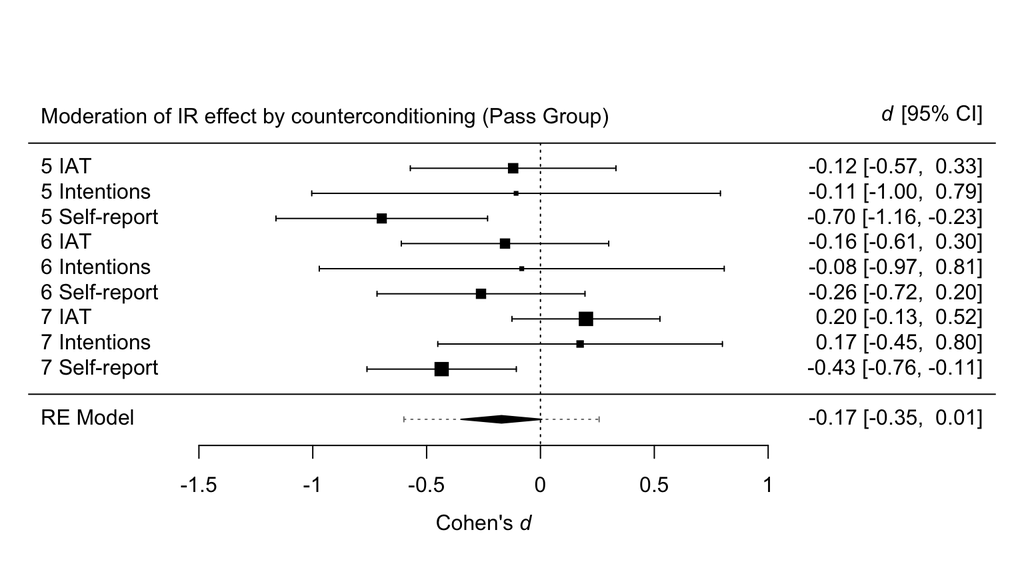

```r
results_for_meta_counterconditioning_ir_sensitivity <- data_processed_after_exclusions_sensitivity %>%
  filter(experiment_condition %in% c("acquisition_only", "acquisition_and_counterconditioning") &
           experiment %in% c(5, 6, 7)) %>%
  rename(IV = experiment_condition) %>%
  mutate(IV = fct_relevel(IV, "acquisition_and_counterconditioning", "acquisition_only")) %>%
  gather(DV_type, DV, c(self_reported_IR_effect_controlling_stimulus_identity,
                        IAT_D2_controlling_stimulus_identity)) %>%
  select(experiment, DV_type, DV, IV) %>%
  drop_na() %>%
  analysis_workflow(data = .) %>%
  rename(yi = cohens_d) %>%
  mutate(sei = (cohens_d_ci_upper - cohens_d_ci_lower)/(2*1.96)) %>%
  select(experiment, DV_type, yi, sei) %>%
  filter(DV_type %in% c("IAT_D2_controlling_stimulus_identity", "self_reported_IR_effect_controlling_stimulus_identity"))

results_moderation_extinction_intentions_ir_sensitivity <- data_processed_after_exclusions_sensitivity %>%
  filter(experiment_condition %in% c("acquisition_only", "acquisition_and_counterconditioning") &
           experiment %in% c(5, 6, 7) &
           behavioral_intentions_IR %in% c("brand_A", "brand_B")) %>%
  count(experiment, experiment_condition, behavioral_intentions_IR) %>%
  spread(behavioral_intentions_IR, n) %>%
  # Haldane-Anscombe correction
  group_by(experiment) %>%
  mutate(count_zero = as.logical(max(c(is.na(brand_A), is.na(brand_B))))) %>%
  ungroup() %>%
  mutate(brand_A = ifelse(count_zero, brand_A+1, brand_A),
         brand_A = ifelse(is.na(brand_A), 1, brand_A),
         brand_B = ifelse(count_zero, brand_B+1, brand_B),
         brand_B = ifelse(is.na(brand_B), 1, brand_B)) %>%
  select(experiment, experiment_condition, brand_A, brand_B) %>%
  pivot_wider(names_from = experiment_condition,
              values_from = c(brand_A, brand_B)) %>%
  escalc(measure = "OR",
         ai = brand_A_acquisition_only,
         bi = brand_B_acquisition_only,
         ci = brand_A_acquisition_and_counterconditioning,
         di = brand_B_acquisition_and_counterconditioning,
         data = .) %>%
  mutate(sei = sqrt(logOR_to_d(vi)),
         yi = logOR_to_d(yi),
         DV_type = "Intentions") %>%
  select(experiment, DV_type, yi, sei)

fit_moderation_by_counterconditioning_ir_sensitivity <-
  bind_rows(results_for_meta_counterconditioning_ir_sensitivity,
            results_moderation_extinction_intentions_ir_sensitivity) %>%
  mutate(DV_type = dplyr::recode(DV_type,
                                 "IAT_D2_controlling_stimulus_identity" = "IAT",
                                 "self_reported_IR_effect_controlling_stimulus_identity" = "Self-report",
                                 "Intentions" = "Intentions")) %>%
  arrange(experiment, DV_type) %>%
  rma.mv(yi      = yi,
         V       = sei^2,
         random  = ~ DV_type | experiment,
         data    = .,
         slab    = paste(experiment, DV_type))

forest(fit_moderation_by_counterconditioning_ir_sensitivity,
       xlab = substitute(paste("Cohen's ", italic('d'))),
       addcred = TRUE,
       refline = 0,
       xlim = c(-2.25, 2),
       at = c(-1.5, -1, -0.5, 0, 0.5, 1))
text(-2.25, 11, "Moderation of IR effect by counterconditioning (Pass Group)", pos = 4)
text(2, 11, substitute(paste(italic('d'), " [95% CI]")), pos = 2)
```

```r
# save model fits for making pdf plots for publication
write_rds(fit_moderation_by_counterconditioning_ir_sensitivity,
          "models/fit_moderation_by_counterconditioning_ir_sensitivity.rds")

congruence_with_full_sample_counterconditioning_ir <-
  ifelse((fit_moderation_by_counterconditioning_ir$ci.lb > 0 & fit_moderation_by_counterconditioning_ir_sensitivity$ci.lb > 0) |
           (fit_moderation_by_counterconditioning_ir$ci.ub < 0 & fit_moderation_by_counterconditioning_ir_sensitivity$ci.ub < 0) |
           (fit_moderation_by_counterconditioning_ir$ci.lb < 0 & fit_moderation_by_counterconditioning_ir_sensitivity$ci.lb < 0 &
              fit_moderation_by_counterconditioning_ir$ci.ub > 0 & fit_moderation_by_counterconditioning_ir_sensitivity$ci.ub > 0),
         "Conclusions about the signficance of the estimate of the effect were congruent between the meta-analysis and sensitivity analysis.", "Conclusions about the signficance of the estimate of the effect were incongruent between the meta-analysis and sensitivity analysis.")
```

Conclusions about the signficance of the estimate of the effect were congruent between the meta-analysis and sensitivity analysis.

### OEC

multilevel meta

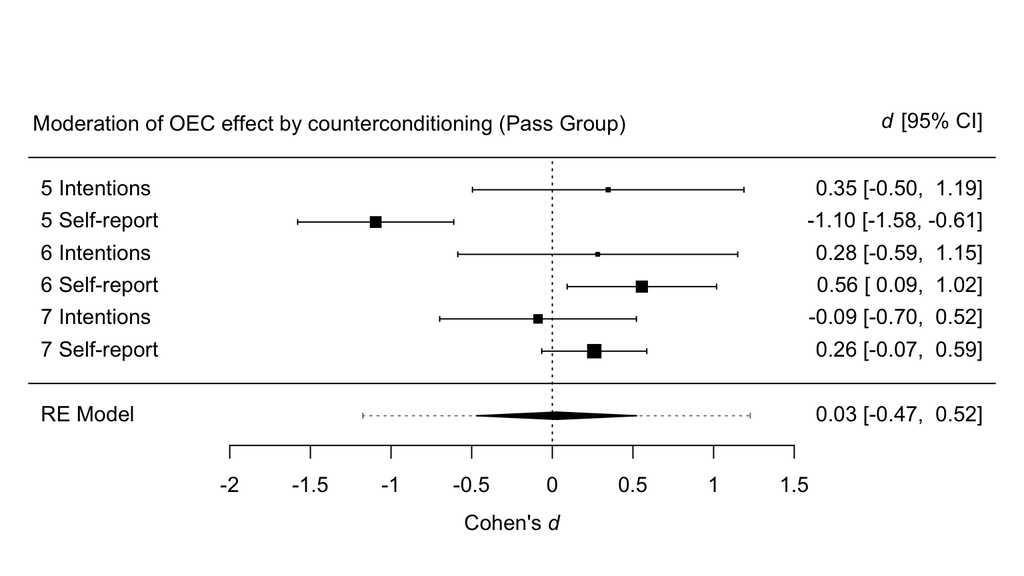

```r
results_for_meta_counterconditioning_oec_sensitivity <- data_processed_after_exclusions_sensitivity %>%
  filter(experiment_condition %in% c("acquisition_only", "acquisition_and_counterconditioning") &
           experiment %in% c(5, 6, 7)) %>%
  rename(IV = experiment_condition) %>%
  mutate(IV = fct_relevel(IV, "acquisition_and_counterconditioning", "acquisition_only")) %>%
  gather(DV_type, DV, c(self_reported_OEC_effect_controlling_stimulus_identity)) %>%
  select(experiment, DV_type, DV, IV) %>%
  drop_na() %>%
  analysis_workflow(data = .) %>%
  rename(yi = cohens_d) %>%
  mutate(sei = (cohens_d_ci_upper - cohens_d_ci_lower)/(2*1.96)) %>%
  select(experiment, DV_type, yi, sei) %>%
  filter(DV_type %in% c("self_reported_OEC_effect_controlling_stimulus_identity"))

results_moderation_extinction_intentions_oec_sensitivity <- data_processed_after_exclusions_sensitivity %>%
  filter(experiment_condition %in% c("acquisition_only", "acquisition_and_counterconditioning") &
           experiment %in% c(5, 6, 7) &
           behavioral_intentions_OEC %in% c("brand_A", "brand_B")) %>%
  count(experiment, experiment_condition, behavioral_intentions_OEC) %>%
  spread(behavioral_intentions_OEC, n) %>%
  # Haldane-Anscombe correction
  group_by(experiment) %>%
  mutate(count_zero = as.logical(max(c(is.na(brand_A), is.na(brand_B))))) %>%
  ungroup() %>%
  mutate(brand_A = ifelse(count_zero, brand_A+1, brand_A),
         brand_A = ifelse(is.na(brand_A), 1, brand_A),
         brand_B = ifelse(count_zero, brand_B+1, brand_B),
         brand_B = ifelse(is.na(brand_B), 1, brand_B)) %>%
  select(experiment, experiment_condition, brand_A, brand_B) %>%
  pivot_wider(names_from = experiment_condition,
              values_from = c(brand_A, brand_B)) %>%
  escalc(measure = "OR",
         ai = brand_A_acquisition_only,
         bi = brand_B_acquisition_only,
         ci = brand_A_acquisition_and_counterconditioning,
         di = brand_B_acquisition_and_counterconditioning,
         data = .) %>%
  mutate(sei = sqrt(logOR_to_d(vi)),
         yi = logOR_to_d(yi),
         DV_type = "Intentions") %>%
  select(experiment, DV_type, yi, sei)

fit_moderation_by_counterconditioning_oec_sensitivity <-
  bind_rows(results_for_meta_counterconditioning_oec_sensitivity,
            results_moderation_extinction_intentions_oec_sensitivity) %>%
  mutate(DV_type = dplyr::recode(DV_type,
                                 "self_reported_OEC_effect_controlling_stimulus_identity" = "Self-report",
                                 "Intentions" = "Intentions")) %>%
  arrange(experiment, DV_type) %>%
  rma.mv(yi      = yi,
         V       = sei^2,
         random  = ~ DV_type | experiment,
         data    = .,
         slab    = paste(experiment, DV_type))

forest(fit_moderation_by_counterconditioning_oec_sensitivity,
       xlab = substitute(paste("Cohen's ", italic('d'))),
       addcred = TRUE,
       refline = 0,
       xlim = c(-3.25, 2.75),
       at = c(-2.0, -1.5, -1, -0.5, 0, 0.5, 1, 1.5))
text(-3.3, 8, "Moderation of OEC effect by counterconditioning (Pass Group)", pos = 4)
text(2.75, 8, substitute(paste(italic('d'), " [95% CI]")), pos = 2)
```

```r
# save model fits for making pdf plots for publication
write_rds(fit_moderation_by_counterconditioning_oec_sensitivity,
          "models/fit_moderation_by_counterconditioning_oec_sensitivity.rds")

congruence_with_full_sample_counterconditioning_oec <-
  ifelse((fit_moderation_by_counterconditioning_oec$ci.lb > 0 & fit_moderation_by_counterconditioning_oec_sensitivity$ci.lb > 0) |
           (fit_moderation_by_counterconditioning_oec$ci.ub < 0 & fit_moderation_by_counterconditioning_oec_sensitivity$ci.ub < 0) |
           (fit_moderation_by_counterconditioning_oec$ci.lb < 0 & fit_moderation_by_counterconditioning_oec_sensitivity$ci.lb < 0 &
              fit_moderation_by_counterconditioning_oec$ci.ub > 0 & fit_moderation_by_counterconditioning_oec_sensitivity$ci.ub > 0),
         "Conclusions about the signficance of the estimate of the effect were congruent between the meta-analysis and sensitivity analysis.", "Conclusions about the signficance of the estimate of the effect were incongruent between the meta-analysis and sensitivity analysis.")
```

Conclusions about the signficance of the estimate of the effect were congruent between the meta-analysis and sensitivity analysis.